# Practical Time Series Analysis

# Week-1

## Datasets

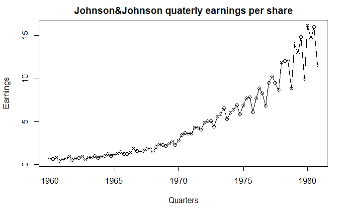

```r
# install.packages("astsa")
require(astsa)
plot(jj, type='o',
main='Johnson&Johnson quaterly earnings per share',
xlab='Quarters', ylab='Earnings')
```

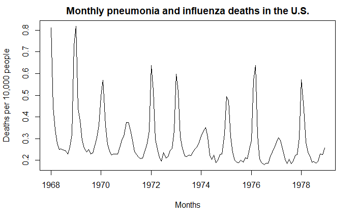

```r
plot(astsa:: flu,
main='Monthly pneumonia and influenza deaths in the U.S.',
xlab='Months', ylab='Deaths per 10,000 people')
```

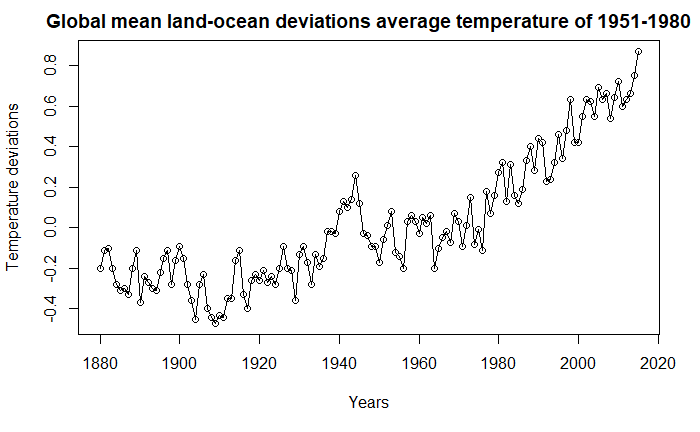

```r
plot(astsa:: globtemp, type='o',
main='Global mean land-ocean deviations average temperature of 1951-1980',
xlab='Years', ylab='Temperature deviations')
```

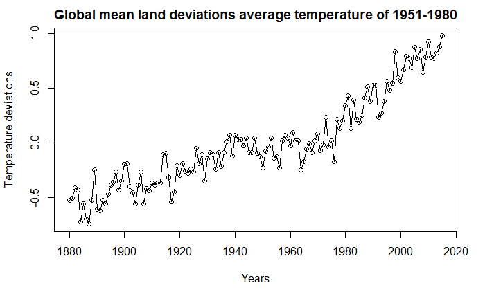

```r
plot(astsa:: globtempl, type='o',
main='Global mean land deviations average temperature of 1951-1980',
xlab='Years', ylab='Temperature deviations')
```

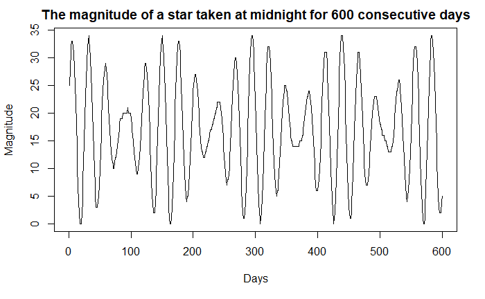

```r
plot(astsa:: star,
main='The magnitude of a star taken at midnight for 600 consecutive days',
xlab='Days', ylab='Magnitude')
```

## Notation

- $\mathrm{E}$: expected value
- $\mu$: average (expected estimation)
- $\mathrm{V}$, $\mathrm{Var}$ : variance
- $\sigma$: standard error (estimated root squared variance)
- $\rho$: correlation
- $r$: correlation estimation
- $\mathrm{cov}$: covariance
- $k$, $\tau$: lag
- $IID$, $iid$: independent, identically distributed
- $\mathcal{N}$: normal distribution
- $\epsilon$: error
- $\mathrm{\gamma}$: autocovariance function
- $X_t$: discrete
- $X(t)$: continuous

## (weak) Stationarity

1. no systematic changes in the mean (no trend, not even piecewise)
2. no systematic changes in variance
3. no periodic fluctuations (seasonality)

$$\mathrm{E}[\epsilon_i] = 0 \\
\mathrm{V}[\epsilon_i] = \sigma^2{\epsilon_i} = \text{constant} = \sigma^2 \\
\mathrm{cov}[\epsilon_i,\epsilon_j] = \sigma\{\epsilon_i, \epsilon_j\} = 0 \quad \forall i \neq j$$

## Regression Model assumptions

When we find estimates of the slope and intercept using, for example Ordinary Least Squares (OLS), we are not really making any distributional assumptions, just taking a cloud of points and finding numbers that we call a slope and an intercept that minimize a quality term.

If we wish to perform some inferences (confidence intervals, hypothesis tests), then we need to make distributional assumptions. Generally, we make the (often reasonable!) assumptions that the errors are (weak) stationary) and normal distributed, e.g., the errors

1. are normally distributed and, on average, zero;
2. all have the same variance (they are homoscedastic), and
3. are unrelated to each other (they are independent across observations).

$$\epsilon_i \stackrel{iid}{\sim} \mathcal{N} ( \mu=0, \; \sigma^2 = \text{constant} )$$

## Variance

It measures the “dispersion” for 1 random variable

$$\sigma^2 \equiv \mathrm{V}[X] \equiv \mathrm{E}[ (X - \mu_X) (X - \mu_X) ]$$

$$V[X+Y] = V[X] + V[Y] + 2\;\mathrm{cov}(X,Y) \\
V[aX] = a^2 V[X]$$

## Covariance

A linear dependence measure between 2 random variables

$$\mathrm{COV}[X, Y] \equiv \mathrm{E}\left[ (X - \mu_X) (Y - \mu_Y) \right] \\
\mathrm{COV}[X, Y] = \mathrm{E}\left[ X \cdot Y \right] - \mathrm{E}\left[ X \right] \mathrm{E}\left[ Y \right]$$

Autocovariance

$$\mathrm{COV}[X, X] = \mathrm{E}\left[ (X - \mu_X) (X - \mu_X) \right] = V[X] = \sigma_X^2$$

## Correlation

Like an adimensional covariance

$$\mathrm{\rho}[X, Y] \equiv \mathrm{E}\left[ \left(\frac{X - \mu_X}{\sigma_X}\right) \left(\frac{Y - \mu_Y}{\sigma_Y}\right) \right]$$

## Stochastic process

A collection of random variables that follows a distribution (let’s say a normal one):

$$X_t \sim \mathcal{N} ( \mu, \; \sigma^2 )$$

An individual trajectory is a realization of a stochastic process, our time series.

The set of all possible trajectories is called the ensemble.

## Mean function

$$\mu(t) \equiv \mu_t \equiv E[X(t)]$$

## Variance function

$$\sigma^2(t) \equiv \sigma^2_t \equiv V[X(t)]$$

## Autocovariance function

$$\gamma(s,t) = \mathrm{Cov}[X_s,X_t] = \mathrm{E}\left[ (X_s - \mu_s) (X_t - \mu_t) \right]$$

In particular

$$\gamma(t,t) = \mathrm{E}\left[ (X_t - \mu_t)^2 \right] = \mathrm{V}[X_t] = \sigma_t^2$$

For a process with lag k

$$\mathrm{COV}[X_t, X_{t+k}] = \mathrm{E}\left[ X_{t} \cdot X_{t+k} \right] - \mathrm{E}\left[ X_{t} \right] \mathrm{E}\left[ X_{t+k} \right]$$

## Autocorrelation function (ACF)

variable and lagged variable

- weak stationarity

AC coefficient
$$-1 \le \rho_k - \frac{\gamma_k}{\gamma_0} \le 1$$

Estimation of autocorrelation coefficient
$$r_k = \frac{c_k}{c_0}$$

Any time series has correlation 1 with itself, i.e., autocorrelation at lag 0 is 1.

## Weak stationary discrete process

None assumptions about distributions.

1. Mean function is constant
2. Autocovariance function depends only from the lag $\tau$
3. From 2, the variance is also constant

$$\mu(t) = \mu \\
\gamma(t_1,t_2) = \gamma(t_2-t_1) = \gamma(\tau) \\
\implies \gamma(t,t) = \gamma(\tau=0) = \sigma^2(t) = \sigma^2$$

Let’s linearly combine the current and a lagged value and compute its variance (since the latter is a squared term, it is therefore non-negative)

$$V[a X (t) + b X (t+\tau)] \geq 0$$

After we apply variance properties

$$a^2 V[ X (t) ] + b^2 V[ X (t+\tau) ] + 2 ab \;\mathrm{cov}\left( X(t),X(t+\tau) \right) \geq 0$$

For a weak stationary process, the variance is constant

$$a^2 \sigma^2 + b^2 \sigma^2 + 2 ab \;\mathrm{cov}\left( X(t),X(t+\tau) \right) \geq 0$$

For $a=b=1$:

$$\sigma^2 + \sigma^2 + 2 \;\mathrm{cov}\left( X(t),X(t+\tau) \right) \geq 0 \\ \sigma^2 + \mathrm{cov}\left( X(t),X(t+\tau) \right) \geq 0 \\
\gamma(0) + \gamma(\tau) \geq 0 \\
\frac{\gamma(0)}{\gamma(0)} + \frac{\gamma(\tau)}{\gamma(0)} \geq 0 \\
1 + \rho(\tau) \geq 0 \\
\rho(\tau) \geq -1$$

For $a=1,\;b=-1$:

$$\sigma^2 + \sigma^2 - 2 \;\mathrm{cov}\left( X(t),X(t+\tau) \right) \geq 0 \\ \sigma^2 - \mathrm{cov}\left( X(t),X(t+\tau) \right) \geq 0 \\
\gamma(0) - \gamma(\tau) \geq 0 \\
\frac{\gamma(0)}{\gamma(0)} - \frac{\gamma(\tau)}{\gamma(0)} \geq 0 \\
1 - \rho(\tau) \geq 0 \\
1 \geq \rho(\tau)$$

Therefore

$$-1 \le \rho(t) \le 1$$

## Strict stationarity

The joint distribution of the full set of random variables is usually unknown.

Joint distribution of $X(t_1), \cdots, X(t_k)$ is the same as the joint distribution of $X(t_1+\tau), \cdots, X(t_k+\tau)$

Implications

## White noise

$$X_t \stackrel{iid}{\sim} \mathcal{N} ( \mu=0, \; \sigma^2 = \text{constant} )$$

Autocovariance function:

#TODO: ENTENDER AUTOCOVARIANCE

$$\gamma(t_1,t_2)=
\begin{cases}
0 & t_1 \neq t_2 \\
\sigma^2 & t_1 = t_2
\end{cases}$$

Autocorrelation function:

$$\rho(t_1,t_2)=
\begin{cases}
0 & t_1 \neq t_2 \\
1 & t_1 = t_2
\end{cases}$$

As the mean and variance are constant along the time and there is no seasonality, it is a weak stationary process.

## Random walk

$$X_t = X_{t-1} + Z_t(\mathcal{N}(\mu=0,\sigma^2=1))$$

Random walk is the accumulation of random deviations from previous steps until the current time.

$$X_1 = Z_1 \\
X_2 = X_1 + Z_2 = Z_1 + Z_2 \\
X_3 = X_2 + Z_3 = Z_1 + Z_2 + Z_3$$

For random variables, the mean of the sum is the sum of the means:

$$\mathrm{E}[X_t] = \mathrm{E}\left[ \sum_{i=1}^{t} Z_i \right] = \sum_{i=1}^{t} \mathrm{E}\left[ Z_i \right] = t \mu$$

For independent random variables, the variance of the sum is the sum of the variances.

$$\mathrm{V}[X_t] = \mathrm{V}\left[ \sum_{i=1}^{t} Z_i \right] = \sum_{i=1}^{t} \mathrm{V}\left[ Z_i \right] = t \sigma^2$$

So random walk is not a stationary process, since even when $\mu=0$, its variance increase over time

One can obtain a stationary stochastic process from the random walk using the difference operator.

## Moving average

The current value of the process now is a linear combination of the noises from current and past time steps. Autocorrelation function of the process cuts off and becomes zero at the order $q$ of the process.

$$Z_t \stackrel{iid}{\sim} \mathcal{N} ( E[Z_t]=0, \; V[Z_t]=\sigma_Z^2 )$$

$$MA(q)\text{ process:}\qquad X_t = \sum_{i=0}^q {\beta_i Z_{t-i}}$$

Mean function

$$E[X_t] = \beta_0 E[Z_t] + \beta_1 E[Z_{t-1}] +\cdots+ \beta_q E[Z_{t-q}] = 0$$

Variance function

$$V[X_t] = \beta_0^2 V[Z_t] + \beta_1^2 V[Z_{t-1}] +\cdots+ \beta_q^2 V[Z_{t-q}] = \sigma_Z^2 \sum_{i=0}^q {\beta_i^2}$$

Covariance function, lag k

$$\mathrm{cov}[X_t, X_{t+k}] =
\mathrm{cov}\left[
\beta_0 Z_t + \beta_1 Z_{t-1} +\cdots+ \beta_q Z_{t-q}, \\
\qquad \qquad \qquad \qquad \qquad \quad \beta_0 Z_{t+k} + \beta_1 Z_{t+k-1} +\cdots+ \beta_q Z_{t+k-q} \right]$$

$$\mathrm{COV}[X_t, X_{t+k}] = \mathrm{E}\left[ X_{t} \cdot X_{t+k} \right] - \mathrm{E}\left[ X_{t} \right] \mathrm{E}\left[ X_{t+k} \right]$$

As the mean function is zero.

$$\mathrm{E}\left[ X_{t} \right] = \mathrm{E}\left[ X_{t+k} \right] = 0 \implies
\mathrm{COV}[X_t, X_{t+k}] = \mathrm{E}\left[ X_{t} \cdot X_{t+k} \right]$$

$$E\left[ \left(
\beta_0 Z_t + \beta_1 Z_{t-1} +\cdots+ \beta_q Z_{t-q} \right) \cdot
\left( \beta_0 Z_{t+k} + \beta_1 Z_{t+k-1} +\cdots+ \beta_q Z_{t+k-q} \right) \right] \\
= E\begin{bmatrix}
\beta_0\beta_0 Z_{t}Z_{t+k} + \beta_0 \beta_1 Z_{t}Z_{t+k-1} +\cdots+ \beta_0\beta_q Z_{t}Z_{t+k-q} \\
+\\
\beta_1\beta_0 Z_{t-1}Z_{t+k} + \beta_1 \beta_1 Z_{t-1}Z_{t+k-1} +\cdots+ \beta_1\beta_q Z_{t-1}Z_{t+k-q} \\
+\\
\beta_q\beta_0 Z_{t-q}Z_{t+k} + \beta_q \beta_1 Z_{t-q}Z_{t+k-1} +\cdots+ \beta_q\beta_q Z_{t-q}Z_{t+k-q}
\end{bmatrix}$$

$$\mathrm{E}\left[ Z_{t} \cdot Z_{t+i} \right] =
\begin{cases}
\mathrm{E}\left[ Z_{t} \right] \cdot \mathrm{E}\left[ Z_{t+i} \right] = 0 & t \neq t+i \\
\mathrm{E}\left[ Z_{t} \right] \cdot \mathrm{E}\left[ Z_{t} \right] = V[Z_{t}] = \sigma^2 & t = t+i
\end{cases}
%= \mathrm{E}\left[ X_{t} \right] \cdot \mathrm{E}\left[ X_{t+k} \right] =$$

For $k=0$, only at the main diagonal we refer to the same instant.

$$\mathrm{COV}[X_t, X_{t}] = E\begin{bmatrix}
\beta_0\beta_0 Z_{t}Z_{t} + 0 +\cdots+ 0 \\
+\\
0 + \beta_1 \beta_1 Z_{t-1}Z_{t-1} +\cdots+ 0 \\
+\\
0 + 0 +\cdots+ \beta_q\beta_q Z_{t-q}Z_{t-q}
\end{bmatrix}
= \sigma^2 \sum_{i=0}^{q} \beta_i^2$$

For $k=1$, only a shift diagonal contains terms at the same instant.

$$\mathrm{COV}[X_t, X_{t}] = E\begin{bmatrix}
0 + \beta_0\beta_1 Z_{t}Z_{t} +\cdots+ 0 \\
+\\
0 + 0 + \beta_1 \beta_2 Z_{t-1}Z_{t-1} +\cdots+ 0 \\
+\\
0 + 0 +\cdots+ 0
\end{bmatrix}
= \sigma^2 \sum_{i=0}^{q-1} \beta_i\beta_{i+1}$$

For $k=q$,

$$\mathrm{COV}[X_t, X_{t}] = E\begin{bmatrix}
0 + 0 +\cdots+ \beta_0\beta_q Z_{t}Z_{t+q-q} \\
+\\
0 + 0 +\cdots+ 0 \\
+\\
0 + 0 +\cdots+ 0
\end{bmatrix}
= \sigma^2 \beta_0\beta_q$$

Generic $k\leq q$, inspecting the coefficients

$$\mathrm{cov} [X_t, X_{t+k}] =
\mathrm{cov} \left[ \left(
\beta_0 Z_t + \beta_1 Z_{t-1} +\cdots+ \beta_q Z_{t-q} \right) \cdot
\left( \beta_0 Z_{t+k} + \beta_1 Z_{t+k-1} +\cdots+ \beta_q Z_{t+k-q} \right) \right]$$

$$\begin{matrix}
Z_{t-q} & Z_{t-(q-1)} & \cdots & Z_{t-(q-k)} & \cdots & Z_{t-1} & Z_{t} & \cdots & & \\
\beta_{q} & \beta_{q-1} & \cdots & \beta_{q-k} & \cdots & \beta_{1} & \beta_{0} & \cdots & 0 & 0 \\
& & \cdots & Z_{t+k-q} & \cdots & Z_{t+k-(k+1)} & Z_{t+k-k} & \cdots & Z_{t+k-1} & Z_{t+k} \\
0 & 0 & \cdots & \beta_{q} & \cdots & \beta_{k+1} & \beta_{k} & \cdots & \beta_{1} & \beta_{0} \\
\end{matrix}$$

$$\mathrm{cov} [X_t, X_{t+k}] = \sigma^2 \sum_{i=0}^{q-k}{\beta_i \beta_{i+k}}$$

$$\gamma(t_1,t_2) = \gamma(k) =
\begin{cases}
0 & k > q \\
\sigma_Z^2 \sum_{i=0}^{q-k}{\beta_i \beta_{i+k}} & k \leq q
\end{cases}$$

Since the mean function is constant and the autocovariance function does not depend on time (it depends only from the lag spacing), the moving average is a weak stationary process.

When there is no lag, $k=0$:

$$\gamma(k=0) = \sigma_Z^2 \sum_{i=0}^{q}{\beta_i \beta_{i}}$$

Therefore the autocorrelation function is

$$\rho(k) = \frac{\gamma(k)}{\gamma(0)}
= \frac{\sigma_Z^2 \sum_{i=0}^{q-k}{\beta_i \beta_{i+k}}}{\sigma_Z^2 \sum_{i=0}^{q}{\beta_i \beta_{i}} }
= \frac{\sum_{i=0}^{q-k}{\beta_i \beta_{i+k}}}{\sum_{i=0}^{q}{\beta_i^2}}$$

Theoretically, it is 0 starting at lag 4. But for a time series, it will be some value which is non-significant. Blue lines are significance level

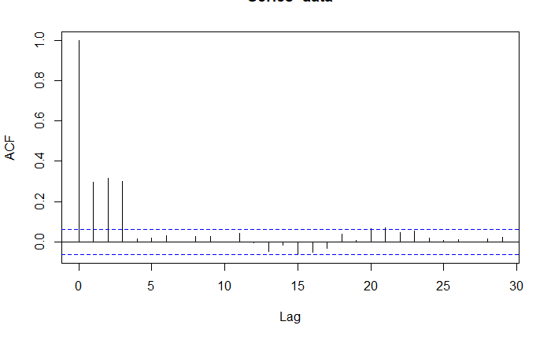

```r
set.seed(2^10)
z=NULL
z=rnorm(1000)
data=NULL
for(i in 4:1000){
  data[i-3]=z[i]+0.2*z[i-1]+0.3*z[i-2]+0.4*z[i-3]
}
data=ts(data)
# find acf below
# blue lines are significance level
acf(data)
```

```r
par( mfrow=c(3,1) );
plot( arima.sim(n=150, list(order=c(0,0,0) )  ), main="WN" );
plot( arima.sim(n=150, list(ma=c(0.33, 0.33, 0.33)      )  ) , main="MA3");
```

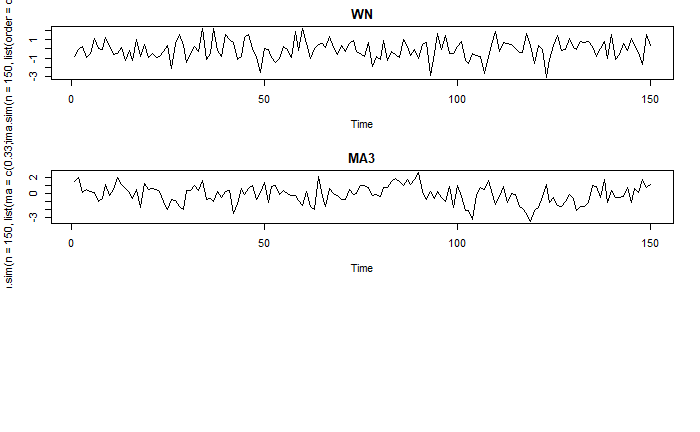

```r
plot( arima.sim(n=150, list(ma=c(0.2, 0.2, 0.2, 0.2, 0.2) )  ), main="MA5" );
```

I don’t get the 0.531 as $\rho(1)$

```
Autocorrelations of series ‘arima.sim(n = 1000, model = list(ma = c(0.5, 0.5)))’, by lag

     0      1      2      3      4      5      6      7      8      9     10     11
 1.000  0.485  0.316 -0.064 -0.063 -0.041  0.022  0.044  0.037 -0.017 -0.036 -0.040
    12     13     14     15     16     17     18     19     20     21     22     23
-0.026  0.005  0.025  0.039  0.002  0.031  0.013  0.052  0.030  0.073  0.081  0.076
    24     25     26     27     28     29     30
 0.026  0.012 -0.009  0.001 -0.009 -0.019 -0.008
```

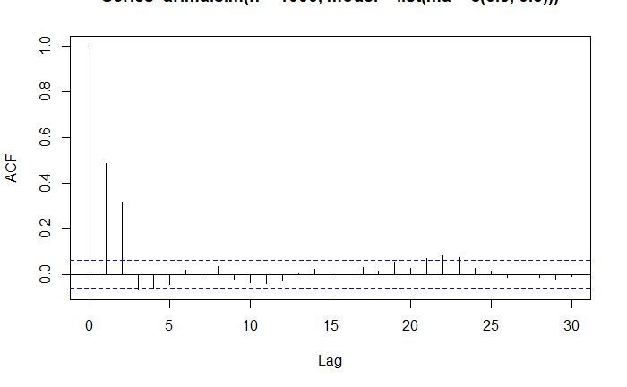

```r
set.seed=1
(acf(arima.sim(n=1000, model=list(ma=c(0.5,0.5)))))
```

## Summary

| Function Process | Mean | Aut o covariance | Variance | Stationary |
| --- | --- | --- | --- | --- |
| **Strict s tationary** | constant | lag dependent | constant | Strict |
| **Weak s tationary** | constant | depends only from lag | constant | Weak |
| **Random walk** | p r oportional to t | p r oportional to t | **p r oportional to t** | No |
| **White noise** | constant | constant | constant | Strict / weak |
| **Moving average** |  |  |  | weak |

# Week-2

## Autoregressive process

Order p

$$X_t=Z_t+history$$

White noise, innovations, random disturbance

$$Z_t\stackrel{iid}{\sim}(\mathcal{N}(\mu=0,\sigma^2=1))$$

History

$$history = \phi_1 X_{t-1} + \cdots + \phi_p X_{t-p}$$

$$AR(p): X_t = Z_t + \phi_1 X_{t-1} + \cdots + \phi_p X_{t-p} \\
MA(q): X_t = \theta_0 Z_{t} + \theta_1 Z_{t-1} + \cdots + \theta_q Z_{t-q}$$

MA: finite set of innovations $Z_t$’s

AR: current innovation $Z_t$ and history of a finite set of prior states $X_t$’s

### Random walk

$$X_t=X_{t-1}+Z_t$$

For $p=\phi_1=1$

$$X_t=X_{t-1}+Z_t$$

```r
set.seed(2016); N=1000; phi = 1;
Z = rnorm(N,0,1); X=NULL; X[1] = Z[1];
for (t in 2:N) {
X[t] = Z[t] + phi*X[t-1] ;
}
X.ts = ts(X)
par(mfrow=c(2,1))
plot(X.ts,main="AR(1) Time Series on White Noise, phi=1")
X.acf = acf(X.ts, main="AR(1) Time Series on White Noise, phi=1")
```

First order AR(1)

```r
set.seed(2016); N=1000; phi = .4;
Z = rnorm(N,0,1); X=NULL; X[1] = Z[1];
for (t in 2:N) {
X[t] = Z[t] + phi*X[t-1] ;
}
X.ts = ts(X)
par(mfrow=c(2,1))
plot(X.ts,main="AR(1) Time Series on White Noise, phi=.4")
X.acf = acf(X.ts, main="AR(1) Time Series on White Noise, phi=.4")

(r.coef = X.acf$acf)
(c (mean(X), var(X)))
```

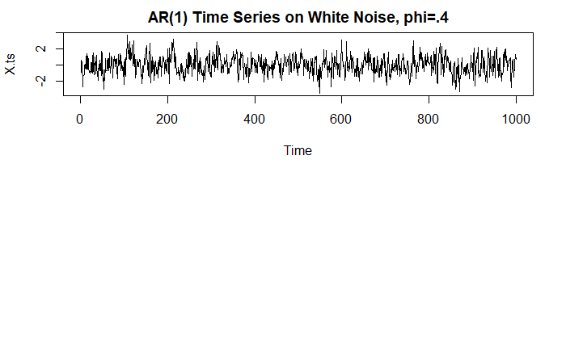

```r
set.seed(2016); N=1000; phi = .4;
Z = rnorm(N,0,1); X=NULL; X[1] = Z[1];
for (t in 2:N) {
X[t] = Z[t] + phi*X[t-1] ;
}
X.ts = ts(X)
par(mfrow=c(2,1))
plot(X.ts,main="AR(1) Time Series on White Noise, phi=.4")
X.acf = acf(X.ts, main="AR(1) Time Series on White Noise, phi=.4")
```

```r
(r.coef = X.acf$acf)
```

```
, , 1

              [,1]
 [1,]  1.000000000
 [2,]  0.401713170
 [3,]  0.177573718
 [4,]  0.119641043
 [5,]  0.071904921
 [6,]  0.047447351
 [7,]  0.034636313
 [8,]  0.023923786
 [9,]  0.012689740
[10,]  0.018391110
[11,] -0.004244947
[12,] -0.033390211
```

[output cut: 19 more lines]

```r
(c (mean(X), var(X)))
```

```
[1] 0.01136599 1.19192721
```

Second order AR(2)

Coefficients range that assure stationarity

$$-1 < \phi_2 <1 \\
\phi_2 < 1 + \phi_1 \\
\phi_2 < 1 - \phi_1$$

```r
X.ts <- arima.sim(list(ar = c(.7, .2)), n=1000)
par(mfrow=c(2,1))
plot(X.ts,main="AR(2) Time Series, phi1=.7, phi2=.2")
X.acf = acf(X.ts, main="Autocorrelation of AR(2) Time Series")
```

```r
phi1 = .4; phi2 = .3;

par(mfrow=c(2,1))
X.ts <- arima.sim(list(ar = c(phi1, phi2)), n=1000)
plot(X.ts,main=paste("AR(2) Time Series, phi1=",phi1,"phi2=",phi2))
acf(X.ts,main="ACF")
```

## Backshift operator

$$AR(p): X_t = Z_t + \phi_1 X_{t-1} + \cdots + \phi_p X_{t-p}$$

$$X_{t-1} = B^1 X_{t} \\
X_{t-2} = B^2 X_{t} \\
\vdots \\
X_{t-p} = B^p X_{t}$$

$$MA(q\to\infty): X_t = \theta_0 Z_{t} + \theta_1 Z_{t-1} + \cdots + \theta_q Z_{t-q} \\
X_t = ( \theta_0 + \theta_1 B + \theta_2 B^2 + \cdots ) Z_{t}$$

MA(q) with a drift

$$X_t = \mu + \theta_0 Z_{t} + \theta_1 Z_{t-1} + \cdots + \theta_q Z_{t-q} \\
X_t - \mu = \Theta(B) Z_t \\
\Theta(B) = \theta_0 + \theta_1 B + \cdots + \theta_q B^q$$

Ex:

MA(2):

$$X_t = Z_t + 0.2 Z_{t-1} + 0.04 Z_{t-2} = (1+0.2B+0.04B^2)Z_t = \beta(B)Z_t$$

First order

$$AR(1): X_t = Z_t + \phi B X_{t} = Z_t + \phi X_{t-1} \\
X_t = Z_t + \phi ( Z_{t-1} + \phi X_{t-2} = Z_t + \phi X_{t-1} + \phi^2 X_{t-2} \\
( 1 - \phi B ) X_{t} = Z_t \\
X_t = \frac{1}{( 1 - \phi B )}Z_t = ( 1 + \phi B + \phi^2 B^2 + \cdots ) Z_t \\
X_t = Z_t + \phi Z_{t-1} + \phi^2 Z_{t-2} + \cdots$$

AR(p), $E[Z_t] = 0, V[Z_t]=\sigma_Z^2$, $V[aX] = a^2 V[X] $

$$E[X_t] = E [ ( 1+\theta_1 B + \theta_2 B^2 + \cdots ) Z_t ] = E [ Z_t ] + \theta_1 E [ Z_{t-1} ] + \cdots + \theta_k E [ Z_{t-k}] + \cdots = 0$$

$$V[X_t] = V [ ( 1+\theta_1 B + \theta_2 B^2 + \cdots ) Z_t ] = V [ Z_t ] + \theta_1^2 V [ Z_{t-1} ] + \cdots + \theta_k^2 V [ Z_{t-k}] + \cdots = \sigma_Z^2(1+\theta_1^2+\cdots+\theta_k^2+\cdots) = \sigma_Z^2 \sum_{i=0}^{\infty}{\theta_i^2}$$

Ex:

AR(2):

$$X_t = Z_t + 0.2 X_{t-1} + 0.3 X_{t-2} = Z_t + (0.2B+0.3B^2)X_t \\
Z_t = (1-0.2B-0.3B^2)X_t = \phi(B)X_t$$

Necessary condition for stationarity. infinite series to converge.

$$\sum_{i=0}^{\infty}{ | \theta_i | }$$

$$MA(q): \gamma(k) = \sigma_Z^2 \sum_{i=0}^{q-k}{\theta_i \theta_{i+k}} \\
AR(p): \gamma(k) = \sigma_Z^2 \sum_{i=0}^{\infty}{\theta_i \theta_{i+k}}$$

$$\rho (k) = \phi_1^k$$

$$\text{White noise}: \phi = 0 \\
\text{Random walk}: \phi = 1 \\
\text{Alternating signal correlation}: \phi < 1\\
\text{First order stationary}: -1 < \phi < 1$$

## Series

Sequence of ordered numbers.

Convergent if $\lim_{n\to\infty}a_n=a$

Ex:

$$a_n = \frac{n}{n+1}:\quad \frac{1}{1+1}=\frac{1}{2}, \frac{2}{2+1}=\frac{2}{3}, \cdots \to 1 \\
a_n = 3^n:\quad 3^1=3, 3^2=9, \cdots \to \infty \\
a_n = \sqrt{n}:\quad \sqrt{1}=1, \sqrt{2}, \cdots \to \infty \\
a_n = \frac{1}{n^2}:\quad \frac{1}{1^2}=1, \frac{1}{2^2}=\frac{1}{4}, \cdots \to 0$$

Partial sums and convergent series sum

$$s_n = \sum_{i=1}^{n} a_i, \quad s = \sum_{i=1}^{\infty} a_i$$

$$\sum_{i=1}^{\infty} \frac{1}{2^i} = 1 \\
\sum_{i=1}^{\infty} \frac{1}{i^2} = \frac{\pi^2}{6} \\
\sum_{i=1}^{\infty} \frac{(-1)^{i+1}}{i} = \ln(2)$$

Divergent

$$\sum_{i=1}^{\infty} 3^i \\
\sum_{i=1}^{\infty} (2i+1) \\
\sum_{i=1}^{\infty} \frac{1}{i}$$

$$a_n = \frac{a_1}{1-r} = \sum_{i=1}^{\infty} a_1 r^{i-1}$$

Ex:

$$\sum_{i=1}^{\infty} \frac{1}{2^i} = \frac{1}{2^1} + \frac{1}{2^2} + \cdots$$

$$a_n = \frac{1}{2^i} \\
a_1 = \frac{1}{2^1} = \frac{1}{2} \\
r = \frac{a_2}{a_1} = \frac{1}{2^2}\frac{2^1}{1} = \frac{1}{2} \\
a_1 r^{i-1} = \frac{1}{2} \frac{1}{2^{i-1}} = \frac{1}{2^{i}} \\
\sum_{i=1}^{\infty} a_1 r^{i-1} = \frac{a_1}{1-r} = \frac{\frac{1}{2}}{1-\frac{1}{2}} = \frac{\frac{1}{2}}{\frac{1}{2}} = 1$$

Ex:

Absolute convergence

$$\sum_{k=1}^{\infty} | a_k |$$

## Geometric series

$$\frac{1}{1-a} = a^0 + a^1 + a^2 + \cdots = \sum_{i=0}^{\infty}a^i, \qquad |a| < 1$$

$$|a|:
\begin{cases}
<1 & \text{convergent} & \text{Ex: } a=\frac{1}{2}; & 1 + \frac{1}{2} + \frac{1}{4} + \frac{1}{8} \cdots \to \frac{1}{1-\frac{1}{2}} = 2 \\
\neq 0 & \text{zero denominator} \\
>1 & \text{divergent} & \text{Ex: } a=2; & 1 + 2 + 4 + 8 + \cdots \to \infty \end{cases}$$

## Invertibility

- $X_t$: stochastic process
- $Z_t$: innovations (random disturbances, white noise)
- $X_t$: invertible, if $Z_t=\sum_{k=0}^{\infty}\pi_{k}X_{t-k}$, where $\sum_{k=0}^{\infty}|\pi_{k}|$ convergent.

Model 1

$$X_t = Z_t + 2 Z_{t-1} \\
\gamma(k) = cov[X_{t+k},X_t] = cov[Z_{t+k} + 2 Z_{t+k-1},Z_t + 2 Z_{t-1}]$$

$$k:
\begin{cases}
<0 & \gamma(k<0) = \gamma(-k>0) \\
= 0 & \gamma(k=0) = cov[Z_{t} + 2 Z_{t-1},Z_t + 2 Z_{t-1}] = cov[Z_{t}, Z_t] + 2^2 cov[Z_{t-1}, Z_{t-1}] = \sigma_Z^2 + 4 \sigma_Z^2 = 5 \sigma_Z^2 \\
=1 & \gamma(k=1) = cov[Z_{t+1} + 2 Z_{t}, Z_t + 2 Z_{t-1}] = cov[2 Z_{t}, Z_t] = 2 \sigma_Z^2 \\
>1 & \gamma(k>1) = 0, \quad \text{since } t+k > t+k-1 > t > t-1 \implies \text{uncorrelated } Z\text{'s}
\end{cases}$$

$$\gamma(k) =
\begin{cases}
\gamma(-k) & k<0 \\
5 \sigma_Z^2 & k=0 \\
2 \sigma_Z^2 & k=1 \\
0 & k>1
\end{cases}$$

$$\rho(k)=\frac{\gamma(k)}{\gamma(0)} = \begin{cases}
\rho(-k) & k<0 \\
1 & k=0 \\
\frac{2}{5} & k=1 \\
0 & k>1
\end{cases}$$

Divergent

$$\sum_{k=0}^{\infty}|\pi_{k}| = \sum_{k=0}^{\infty} 2^{k}$$

```r
theta = c(1.0,2.0)
par( mfrow=c(2,1) );
plot( arima.sim(n=150, list(ma=theta)  ) , main="MA2");

set.seed=1
(acf(arima.sim(n=1000, model=list(ma=theta))))
```

Model 2

$$X_t = Z_t + \frac{1}{2} Z_{t-1} \\
\gamma(k) = cov[X_{t+k}, X_t]
= cov[ Z_{t+k} + \frac{1}{2} Z_{t+k-1}, Z_t + \frac{1}{2} Z_{t-1}] \\
\gamma(0) = cov[ Z_{t} + \frac{1}{2} Z_{t-1}, Z_t + \frac{1}{2} Z_{t-1}]
= cov[Z_{t}, Z_{t}] + \frac{1}{2} cov[Z_{t-1}, Z_{t-1}] = \sigma_Z^2 + \left(\frac{1}{2}\right)^2\sigma_Z^2 = \sigma_Z^2\left(1+\frac{1}{4}\right) \\
\gamma(1) = cov[ Z_{t+1} + \frac{1}{2} Z_{t}, Z_t + \frac{1}{2} Z_{t-1}]
= \frac{1}{2} cov[Z_{t}, Z_{t}] = \frac{1}{2}\sigma_Z^2 \\
\rho(1) = \frac{\gamma(1)}{\gamma(0)} = \frac{\frac{1}{2}\sigma_Z^2}{\sigma_Z^2\left(1+\frac{1}{4}\right)} = \frac{1}{2}\frac{4}{5} = \frac{2}{5}$$

Convergent

$$\sum_{k=0}^{\infty}|\pi_{k}| = \sum_{k=0}^{\infty}\frac{1}{2^{k}}$$

```r
theta = c(1.0,0.5)
par( mfrow=c(2,1) );
plot( arima.sim(n=150, list(ma=theta)  ) , main="MA2");

set.seed=1
(acf(arima.sim(n=1000, model=list(ma=theta))))
```

MA(1) -> AR($\infty$)

$$X_t = Z_t + \beta Z_{t-1} \\
Z_t = X_t - \beta Z_{t-1} = X_t - \beta (X_{t-1} - \beta Z_{t-2} ) = X_t -\beta X_{t-1} +\beta^2 Z_{t-2} \\
Z_t = \sum_{k=0}^{\infty}(-\beta)^kX_{t-k} \\
X_t = Z_t + \sum_{k=1}^{\infty}(-\beta)^{k+1}X_{t-k} \\$$

Convergence: $|\beta|<1$

$$X_t = Z_t + \beta Z_{t-1} = Z_t + \beta B Z_{t} = (1+\beta B)Z_{t} = \beta(B)Z_{t} \\
Z_t = \beta(B)^{-1} X_t \\
\beta(B)^{-1} = \frac{1}{(1+\beta B)} = 1 - \beta B + \beta^2 B^2 +\cdots = \sum_{k=1}^{\infty}(-\beta B)^{k-1} \\$$

1.

$$-3+\frac{3}{2}-\frac{3}{4}+\cdots
= -3 \sum_{k=0}^{\infty}\left(-\frac{1}{2}\right)^{k}\\
a \sum_{k=0}^{\infty} r^{k}
= \frac{a}{1-r}, \text{ if } |r|<1, \text{ convergent} \\
S = \frac{-3}{1-\left(-\frac{1}{2}\right)}
= \frac{-3}{\frac{3}{2}}
= -2$$

2.

$$\frac{4}{1+x}
= \frac{4}{1-(-x)}
= 4 \sum_{k=0}^{\infty} (-x)^{k}
= 4 - 4x + 4x^2 - \cdots \\
\frac{a}{1-r} = a \sum_{k=0}^{\infty} r^{k}$$

3.

$$X_t = 0.5 X_{t-1} + Z_t + 0.7 Z_{t-1} \\
(1-0.5B)X_t = (1 + 0.7B) Z_{t}$$

4. AR(2)

$$X_t = X_{t-1} + 2 X_{t-2} + Z_t \\
(1-B-2B^2)X_t = Z_{t}$$

5.

$$X_{t}=Z_{t}+3Z_{t-1} = (1+3B)Z_{t} \\
1+3B=0 \implies r=-\frac{1}{3} \\
|r| = | -\frac{1}{3} | = \frac{1}{3} < 1 \implies \text{not invertible}$$

6.

$$X_t = Z_t - \theta Z_{t-1} - 6 \theta^2 Z_{t-2} = (1-\theta B-6\theta^2B^2) Z_t \\
1-\theta B-6\theta^2B^2 = 0 \\
S = -\frac{b}{a} = -\frac{-\theta}{-6\theta^2} = -\frac{1}{6\theta} \\
P = \frac{c}{a} = \frac{1}{-6\theta^2} = -\frac{1}{6\theta^2} \\
r_1 = -\frac{1}{2\theta} = -(2\theta)^{-1},\quad r_2 = \frac{1}{3\theta} = (3\theta)^{-1} \\
|r| > 1 \implies \text{invertible} \\
|r_1| = |-(2\theta)^{-1}| = |2\theta|^{-1} > 1 \implies |\theta| < \frac{1}{2} \\
|r_2| = |(3\theta)^{-1}| = |3\theta|^{-1} > 1 \implies |\theta| < \frac{1}{3} \\
\implies |\theta| < \frac{1}{3}$$

7.AR(2)

$$X_t = X_{t-1} + 2 X_{t-2} + Z_t \\
(1-B-2B^2)X_t = Z_{t} \\
1-B-2B^2 = 0 \\
S = -\frac{b}{a} = -\frac{-1}{-2} = -\frac{1}{2} \\
P = \frac{c}{a} = \frac{1}{-2} = -\frac{1}{2} \\
r_1 = -1,\quad r_2 = \frac{1}{2} \\
|r| > 1 \implies \text{invertible and stationary} \\
|r_1| = |-1| = 1 \\
|r_2| = |\frac{1}{2}| = \frac{1}{2} < 1$$

8.AR(2)

$$X_t = 2\beta X_{t-1} - \beta^2 X_{t-2} + Z_t \\
( 1-2\beta B + \beta^2 B^2 ) X_t = Z_t \\
( 1-2\beta B + \beta^2 B^2 ) = 0 \\
S = -\frac{b}{a} = -\frac{-2\beta}{\beta^2} = \frac{2}{\beta} \\
P = \frac{c}{a} = \frac{1}{\beta^2} \\
r_1 = \frac{1}{\beta} = \beta^{-1} = r_2\\
|r| > 1 \implies \text{invertible and stationary} \\
|r| = |\beta^{-1}| = |\beta|^{-1} > 1 \implies |\beta| < 1$$

$$X_t = 0.5 X_{t-1} + Z_t + 4 Z_{t-1} \\
(1-0.5B)X_t = (1 + 4B) Z_{t} \\
(1 + 4B) = 0 \implies r_{MA} = - \frac{1}{4} \\
|r_{MA}| = | - \frac{1}{4} | = \frac{1}{4} < 1 \\
(1-0.5B) = 0 \implies r_{AR} = 2 \\
|r_{AR}| = | 2 | = 2 > 1$$

$$X_t = \beta^2 X_{t-1} + Z_t + 8\theta^3 Z_{t-1} \\
(1-\beta^2 B)X_t = (1 + 8\theta^3 B) Z_{t} \\
(1-\beta^2 B) = 0 \implies r_{MA} = \frac{1}{\beta^2} \\
|r_{MA}| = | (\beta^2)^{-1} | = | \beta | ^{-2} \implies | \beta | < 1 \\
(1 + 8\theta^3 B) = 0 \implies r_{AR} = \frac{1}{-8\theta^3} = -(2\theta)^{-3} \\
|r_{AR}| = | -(2\theta)^{-3} | = | 2\theta | ^{-3} \implies | 2 \theta | < 1 \implies \theta < \frac{1}{2}$$

## Yule Walker

TODO: check material from diff eq and Yule Walker

$$a_n = \lambda^n$$

$$a_n=4a_{n-1}-3a_{n-2} \\
\lambda^2 - 4\lambda+3=0 \\
S = -\frac{b}{a} = -\frac{-4}{1} = 4 \\
P = \frac{c}{a} = \frac{3}{1} = 3 \\
\lambda_1 = 3, \quad \lambda_2=1$$

$$a_{n} = 4a_{n-1} - 3a_{n-2} \\
a_n = c_1 + c_2 3^n \\
a_{2} = 4 a_1 - 3 a_0 = 4 (-2) - 3 (2) = -8 -6 = -14 \\
a_n = 4 - 2 (3^n) \\
a_0 = 4 - 2 (3^0) = 4 -2 = 2 \\
a_1 = 4 - 2 (3^1) = 4 - 6 = -2 \\
a_2 = 4 - 2 (3^2) = 4 - 18 = -14$$

AR(1) starting at lag 1, even function

$$X_t=0.4X_{t-1}+Z_t \\
\rho(k)=0.4\rho(k-1), \quad k \geq 1 \\
\rho(0) = 1 \\
\rho(k) = 0.4^{k}, \quad k \geq 0 \\
\rho(k) = \rho(-k) \quad\forall k \in \mathbb{Z}^{-}$$

AR(3)

$$X_t = \frac{1}{2} X_{t-1} + \frac{1}{9} X_{t-2} - \frac{1}{18} X_{t-3} + Z_{t} \\
18\lambda^3-9 \lambda^2 - 2 \lambda + 1 = 0 \\
(2\lambda-1)(3\lambda-1)(3\lambda+1)=0 \\
\rho(k) = \frac{1}{2} \rho(k-1) + \frac{1}{9} \rho(k-2) - \frac{1}{18} \rho(k-3) \\
\rho(k) = c_1 \left( \frac{1}{2} \right)^k + c_2 \left( \frac{1}{3} \right)^k + c_3 \left( -\frac{1}{3} \right)^k$$

# Week-3

MA(q): ACF cuts off after q lags

AR(p): PACF cuts off after p lags

The excess correlation at 𝑙𝑎𝑔 = 𝑘 not accounted for by a (𝑘 - 1)𝑠𝑡 order model, is the  
partial correlation at lag=k

## PACF

```r
# install.packages("isdals")
library(isdals)
data(bodyfat)
attach(bodyfat)
cor( cbind(Fat, Triceps,Thigh,Midarm) )
```

```
              Fat   Triceps     Thigh    Midarm
Fat     1.0000000 0.8432654 0.8780896 0.1424440
Triceps 0.8432654 1.0000000 0.9238425 0.4577772
Thigh   0.8780896 0.9238425 1.0000000 0.0846675
Midarm  0.1424440 0.4577772 0.0846675 1.0000000
```

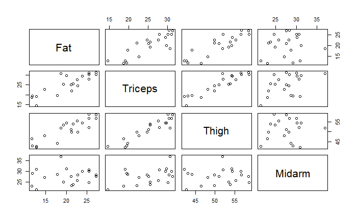

```r
pairs( cbind( Fat, Triceps, Thigh, Midarm) )
```

```r
# Check most correlated variables
# (Fat,Thigh); (Fat,Triceps); (Triceps,Thigh)
Fat.hat = predict(lm(Fat~Thigh))
Triceps.hat = predict( lm(Triceps~Thigh) )
cor( (Fat- Fat.hat), (Triceps- Triceps.hat) ) #returns 0.1749822
```

```
[1] 0.1749822
```

```r
# install.packages("ppcor")
library(ppcor)
pcor( cbind( Fat, Triceps, Thigh) )
```

```
$estimate
              Fat   Triceps     Thigh
Fat     1.0000000 0.1749822 0.4814109
Triceps 0.1749822 1.0000000 0.7130120
Thigh   0.4814109 0.7130120 1.0000000

$p.value
               Fat      Triceps        Thigh
Fat     0.00000000 0.4736789763 0.0368987227
Triceps 0.47367898 0.0000000000 0.0006109801
Thigh   0.03689872 0.0006109801 0.0000000000

$statistic
              Fat   Triceps    Thigh
Fat     0.0000000 0.7327755 2.264597
Triceps 0.7327755 0.0000000 4.192849
Thigh   2.2645969 4.1928494 0.000000

$n
[1] 20

$gp
[1] 1

$method
[1] "pearson"
```

```r
Fat.hat = predict(lm(Fat~Thigh+Midarm))
Triceps.hat = predict( lm(Triceps~Thigh+Midarm) )
cor( (Fat- Fat.hat), (Triceps- Triceps.hat) ) #returns 0.33815
```

```
[1] 0.33815
```

```r
pcor( cbind( Fat, Triceps, Thigh, Midarm) )
```

```
$estimate
               Fat   Triceps      Thigh     Midarm
Fat      1.0000000 0.3381500 -0.2665991 -0.3240520
Triceps  0.3381500 1.0000000  0.9963725  0.9955918
Thigh   -0.2665991 0.9963725  1.0000000 -0.9926612
Midarm  -0.3240520 0.9955918 -0.9926612  1.0000000

$p.value
              Fat      Triceps        Thigh       Midarm
Fat     0.0000000 1.699111e-01 2.848944e-01 1.895628e-01
Triceps 0.1699111 0.000000e+00 1.490492e-18 7.071386e-18
Thigh   0.2848944 1.490492e-18 0.000000e+00 4.134178e-16
Midarm  0.1895628 7.071386e-18 4.134178e-16 0.000000e+00

$statistic
              Fat   Triceps      Thigh     Midarm
Fat      0.000000  1.437266  -1.106441  -1.370142
Triceps  1.437266  0.000000  46.833317  42.459264
Thigh   -1.106441 46.833317   0.000000 -32.834695
Midarm  -1.370142 42.459264 -32.834695   0.000000

$n
[1] 20

$gp
[1] 2

$method
[1] "pearson"
```

```r
par(mfrow=c(3,1))
phi = c(.9, -.6, .3)
data.ts = arima.sim(n = 500, list(ar=phi) )
plot(data.ts, main= paste(c("Autoregressive Process with phi=(", phi , ")"), collapse=" ") )
acf(data.ts)
acf(data.ts, type="partial")
```

```r
par(mfrow=c(3,1))
phi = c(.9, -.6, .3)
data.ts = arima.sim(n = 500, list(ar=phi) )
plot(data.ts, main= paste(c("Autoregressive Process with phi=(", phi , ")"), collapse=" ") )
acf(data.ts)
```

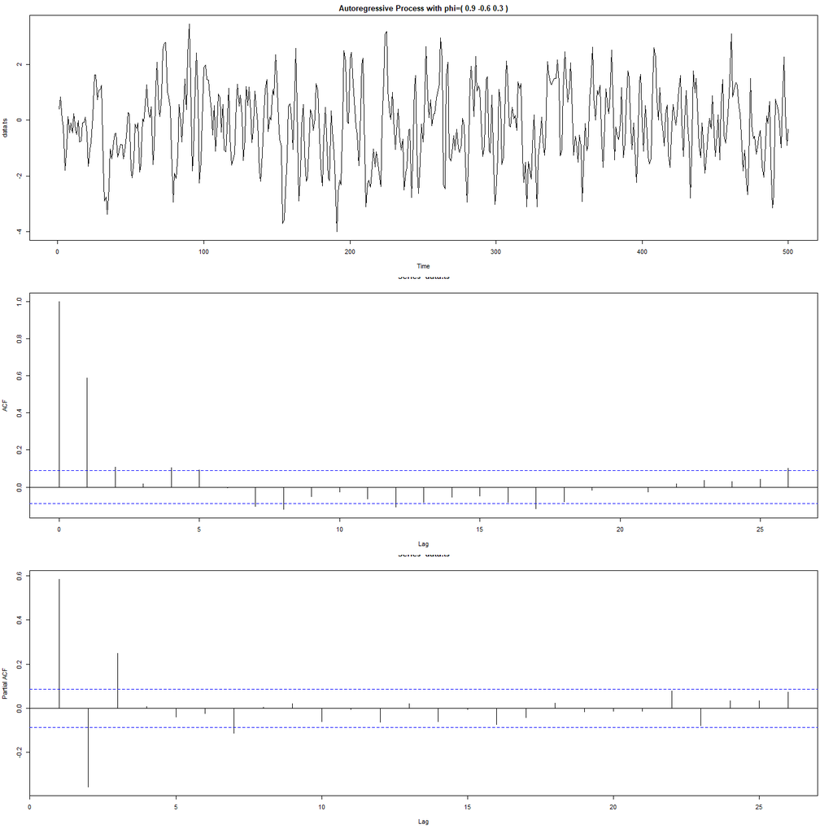

```r
acf(data.ts, type="partial")
```

## Wheat price

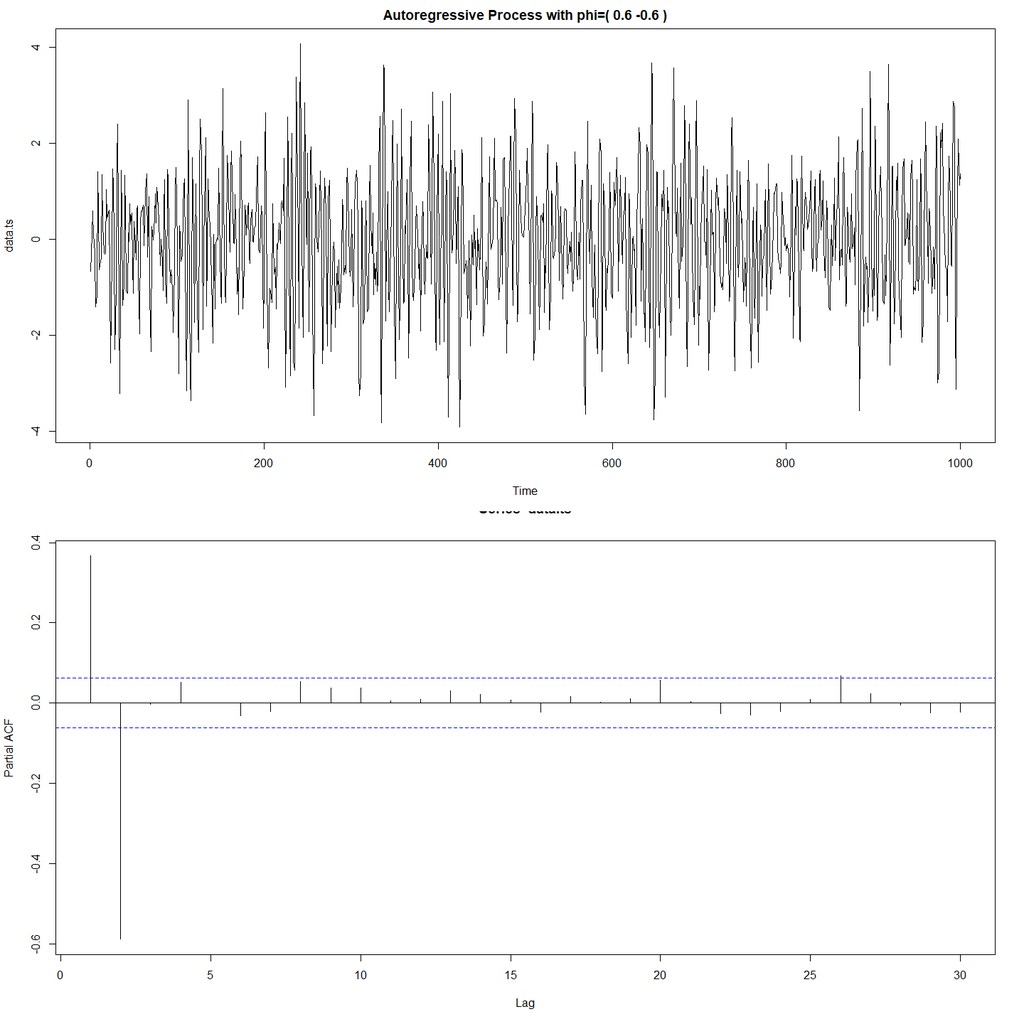

```r
phi = c(.6, -.6)
par(mfrow=c(2,1))
data.ts = arima.sim(n = 1000, list(ar = phi ))
plot(data.ts,
main =
paste(c("Autoregressive Process with phi=(", phi , ")"), collapse=" ") )
acf(data.ts, type="partial")
```

```r
library(data.table)
# Get the data
beveridge <- fread('https://people.sc.fsu.edu/~jburkardt/datasets/time_series/beveridge_wheat.txt')
```

```
 [0%] Downloaded 0 bytes...
```

```r
beveridge.ts = ts(beveridge[,2], start=1500)

# Check MA
mean(beveridge$V2[1:31])
```

```
[1] 18.10645
```

```r
mean(beveridge$V2[2:32])
```

```
[1] 18.49355
```

```r
beveridge.MA = filter(beveridge.ts, rep(1/31, 31), sides = 2)
data.frame(beveridge$V1, beveridge$V2, beveridge.MA)
```

| beveridge.V1 | beveridge.V2 | beveridge.MA |
| --- | --- | --- |
| 1500 | 17.0 | NA |
| 1501 | 19.0 | NA |
| 1502 | 20.0 | NA |
| 1503 | 15.0 | NA |
| 1504 | 13.0 | NA |
| 1505 | 14.0 | NA |
| 1506 | 14.0 | NA |
| 1507 | 14.0 | NA |
| 1508 | 14.0 | NA |
| 1509 | 11.0 | NA |

[output cut: 360 more lines]

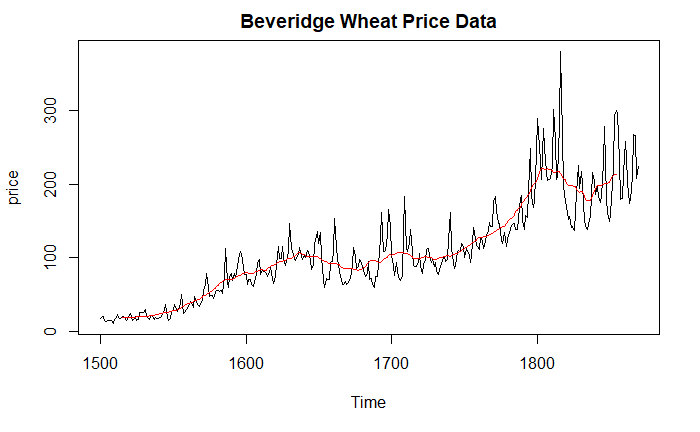

```r
plot( beveridge.ts, ylab="price", main="Beveridge Wheat Price Data")
lines(beveridge.MA, col="red")
```

```r
par(mfrow=c(3,1))
Y = beveridge.ts/beveridge.MA
plot( Y, ylab="scaled price", main="Transformed Beveridge Wheat Price Data")
acf(na.omit(Y),
main="Autocorrelation Function of Transformed Beveridge Data")
```

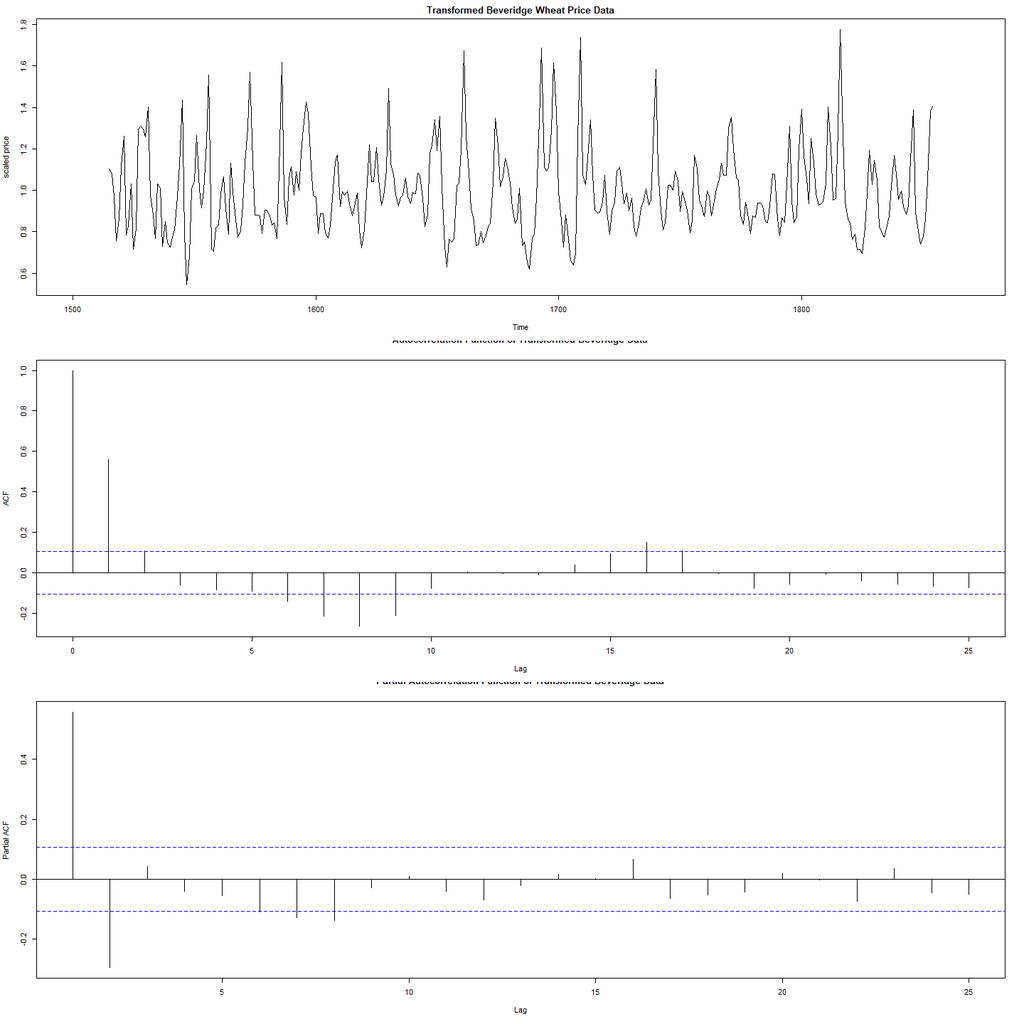

```r
acf(na.omit(Y), type="partial",
main="Partial Autocorrelation Function of Transformed Beveridge Data")
```

```r
ar(na.omit(Y), order.max = 5)
```

```
Call:
ar(x = na.omit(Y), order.max = 5)

Coefficients:
      1        2
 0.7239  -0.2957

Order selected 2  sigma^2 estimated as  0.02692
```

## Partial Correlation

Remove Thigh and Midarm dependencies

$$Triceps(\phi - \hat{\phi}(Thigh,Midarm)), \quad \phi = Fat \\
Fat(\tau - \hat{\tau}(Thigh,Midarm)), \quad \tau = Triceps \\ \\
Triceps \times Fat$$

## Lake Huron

```r
par( mfrow=c(3,1) )
plot(LakeHuron)
acf(LakeHuron)
acf(LakeHuron, type="partial")
```

```r
par( mfrow=c(3,1) )
plot(LakeHuron)
acf(LakeHuron)
```

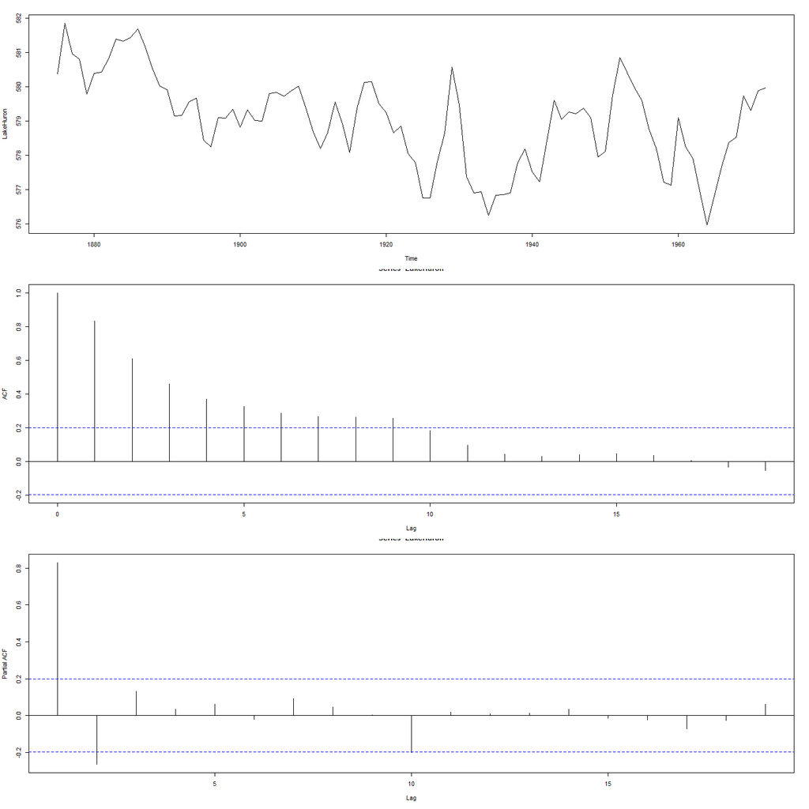

```r
acf(LakeHuron, type="partial")
```

```r
# install.packages("pracma")
require(pracma)  # detrend

LakeHuron.diff = diff(LakeHuron)

par( mfrow=c(3,1) )
plot(LakeHuron.diff)
acf(LakeHuron.diff)$acf[1:3]
```

```
[1]  1.0000000  0.1319241 -0.1870874
```

```
, , 1

             [,1]
 [1,]  0.13192409
 [2,] -0.20811341
 [3,] -0.15554016
 [4,] -0.08125169
 [5,] -0.08032676
 [6,] -0.11498705
 [7,] -0.09921436
 [8,] -0.03345357
 [9,]  0.14449116
[10,] -0.06940743
[11,] -0.09267332
[12,] -0.05752015
[13,] -0.05607594
[14,] -0.02445180
[15,] -0.02259019
[16,]  0.05689401
[17,] -0.02986238
[18,] -0.11855347
[19,] -0.06278721
```

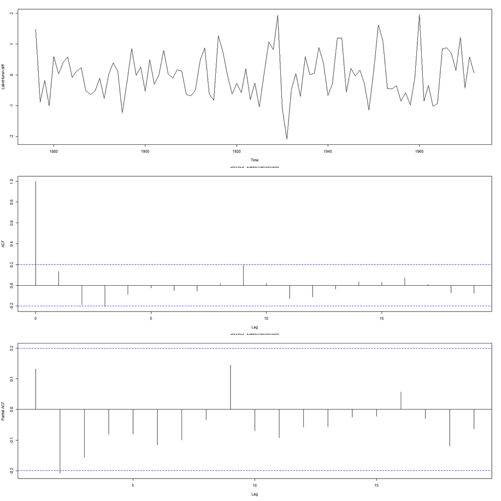

```r
acf(LakeHuron.diff, type="partial")$acf
```

## Attitude

```r
# package: datasets
attach(attitude);
rcl = cbind(rating, complaints, learning);
cor(rcl)

rating.hat = predict( lm( rating ~ learning) )
complaints.hat = predict( lm( complaints~learning) )

cor( (rating - rating.hat ), ( complaints - complaints.hat ) )

pcor(rcl)
```

```r
# package: datasets
attach(attitude);
rcl = cbind(rating, complaints, learning);
cor(rcl)
```

```
              rating complaints  learning
rating     1.0000000  0.8254176 0.6236782
complaints 0.8254176  1.0000000 0.5967358
learning   0.6236782  0.5967358 1.0000000
```

```r
rating.hat = predict( lm( rating ~ learning) )
complaints.hat = predict( lm( complaints~learning) )

cor( (rating - rating.hat ), ( complaints - complaints.hat ) )
```

```
[1] 0.7225924
```

```r
pcor(rcl)
```

```
$estimate
              rating complaints  learning
rating     1.0000000  0.7225924 0.2894561
complaints 0.7225924  1.0000000 0.1856905
learning   0.2894561  0.1856905 1.0000000

$p.value
                 rating   complaints  learning
rating     0.000000e+00 9.573795e-06 0.1277539
complaints 9.573795e-06 0.000000e+00 0.3348403
learning   1.277539e-01 3.348403e-01 0.0000000

$statistic
             rating complaints  learning
rating     0.000000  5.4315631 1.5713241
complaints 5.431563  0.0000000 0.9819539
learning   1.571324  0.9819539 0.0000000

$n
[1] 30

$gp
[1] 1

$method
[1] "pearson"
```

```r
# order
p=2

# sample autocorreleation function r
r=NULL
r[1:p]=acf(ar.process, plot=F)$acf[2:(p+1)]
cat('r=',r,'\n')
```

```
r= 0.9218042 0.7829182
```

```r
# matrix R
R=matrix(1,p,p) # matrix of dimension 2 by 2, with entries all 1's.

# define non-diagonal entires of R
for(i in 1:p){
    for(j in 1:p){
        if(i!=j)
            R[i,j]=r[abs(i-j)]
        }
    }
R
```

```
          [,1]      [,2]
[1,] 1.0000000 0.9218042
[2,] 0.9218042 1.0000000
```

```r
# b-column vector on the right
b=NULL
b=matrix(r,p,1)# b- column vector with no entries
b
```

```
          [,1]
[1,] 0.9218042
[2,] 0.7829182
```

```r
# solve(R,b) solves Rx=b, and gives x=R^(-1)b vector
phi.hat=NULL
phi.hat=solve(R,b)[,1]
phi.hat
```

```
[1]  1.3315874 -0.4445447
```

```r
#variance estimation using Yule-Walker Estimator
c0=acf(ar.process, type='covariance', plot=F)$acf[1]
c0
```

```
[1] 780.991
```

```r
var.hat=c0*(1-sum(phi.hat*r))
var.hat
```

```
[1] 94.17131
```

```r
# constant term in the model
phi0.hat=mean(my.data)*(1-sum(phi.hat))
phi0.hat
```

```
[1] 7.033036
```

```r
cat("Constant:", phi0.hat," Coefficients:", phi.hat, " and Variance:", var.hat, '\n')
```

```
Constant: 7.033036  Coefficients: 1.331587 -0.4445447  and Variance: 94.17131
```

```r
# order
p=2

# sample autocorreleation function r
r=NULL
r[1:p]=acf(ar.process, plot=F)$acf[2:(p+1)]
cat('r=',r,'\n')

# matrix R
R=matrix(1,p,p) # matrix of dimension 2 by 2, with entries all 1's.

# define non-diagonal entires of R
for(i in 1:p){
    for(j in 1:p){
        if(i!=j)
            R[i,j]=r[abs(i-j)]
        }
    }
R

# b-column vector on the right
b=NULL
b=matrix(r,p,1)# b- column vector with no entries
b

# solve(R,b) solves Rx=b, and gives x=R^(-1)b vector
phi.hat=NULL
phi.hat=solve(R,b)[,1]
phi.hat

#variance estimation using Yule-Walker Estimator
c0=acf(ar.process, type='covariance', plot=F)$acf[1]
c0

var.hat=c0*(1-sum(phi.hat*r))
var.hat

# constant term in the model
phi0.hat=mean(my.data)*(1-sum(phi.hat))
phi0.hat

cat("Constant:", phi0.hat," Coefficients:", phi.hat, " and Variance:", var.hat, '\n')
```

## Johnson & Johnson

```r
library(astsa)
# Time plot for Johnson&Johnson
plot(JohnsonJohnson, main='Johnson&Johnosn earnings per share', col='blue', lwd=3)
```

```r
# log-return of Johnson&Johnson
jj.log.return=diff(log(JohnsonJohnson))
jj.log.return.mean.zero=jj.log.return-mean(jj.log.return)

# Plots for log-returns
par(mfrow=c(3,1))
plot(jj.log.return.mean.zero, main='Log-return (mean zero) of Johnson&Johnosn earnings per share')
acf(jj.log.return.mean.zero, main='ACF')
pacf(jj.log.return.mean.zero, main='PACF')
```

```r
# Order
p=4

# sample autocorreleation function r
r=NULL
r[1:p]=acf(jj.log.return.mean.zero, plot=F)$acf[2:(p+1)]
r

# matrix R
R=matrix(1,p,p) # matrix of dimension 4 by 4, with entries all 1's.
# define non-diagonal entires of R
for(i in 1:p){
    for(j in 1:p){
        if(i!=j)
            R[i,j]=r[abs(i-j)]
        }
    }
R

# b-column vector on the right
b=matrix(r,p,1)# b- column vector with no entries
b

phi.hat=solve(R,b)[,1]
phi.hat

# Variance estimation using Yule-Walker Estimator
c0=acf(jj.log.return.mean.zero, type='covariance', plot=F)$acf[1]
c0
var.hat=c0*(1-sum(phi.hat*r))
var.hat

# Constant term in the model
phi0.hat=mean(jj.log.return)*(1-sum(phi.hat))
phi0.hat

cat("Constant:", phi0.hat," Coefficients:", phi.hat, " and Variance:", var.hat, '\n')
```

## Yule-Walker matrix

### AR(2)

x*t=phi1*x*(t-1)+phi2*x_(t-2)+z_t z_t~ N(0, sigma^2)

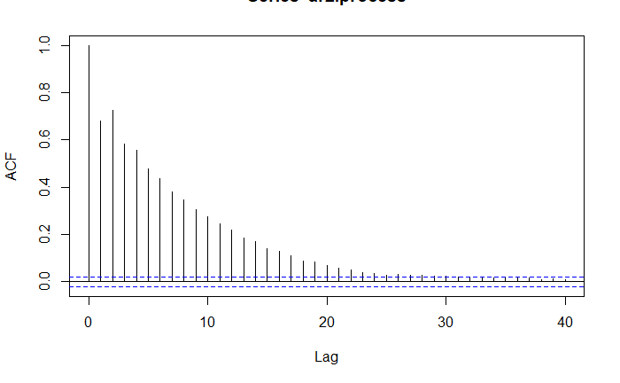

```r
# acf terms
r=NULL
r[1:2]=acf(ar2.process, plot=T)$acf[2:3]  # 1: gamma(0)=1
```

```r
r
```

```
[1] 0.6814103 0.7255825
```

```r
R=matrix(1,2,2) # matrix of dimension 2 by 2, with entries all 1's.
R[1,2]=r[1] # only diagonal entries are edited
R[2,1]=r[1] # only diagonal entries are edited
R
```

```
          [,1]      [,2]
[1,] 1.0000000 0.6814103
[2,] 0.6814103 1.0000000
```

```r
b=matrix(r,nrow=2,ncol=1)# b- column vector with no entries
b
```

```
          [,1]
[1,] 0.6814103
[2,] 0.7255825
```

```r
# coefficients estimation
phi.hat=solve(R,b)
phi.hat
```

```
          [,1]
[1,] 0.3490720
[2,] 0.4877212
```

```r
# variance estimation
c0=acf(ar2.process, type='covariance', plot=F)$acf[1]
var.hat=c0*(1-sum(phi.hat*r))
var.hat
```

```
[1] 16.37169
```

```r
set.seed(2017)
sigma=4
phi=c(1/3,1/2)
n=10000

# simulated ar process
ar2.process=arima.sim(n, model=list(ar=phi), sd=sigma)
ar2.process[1:5]
```

```
[1] 4.087685 5.598492 3.019295 2.442354 5.398302
```

```r
par(mfrow=c(3,1))
plot(ar2.process, main='Simulated AR(2)')
acf(ar2.process, main='ACF')
```

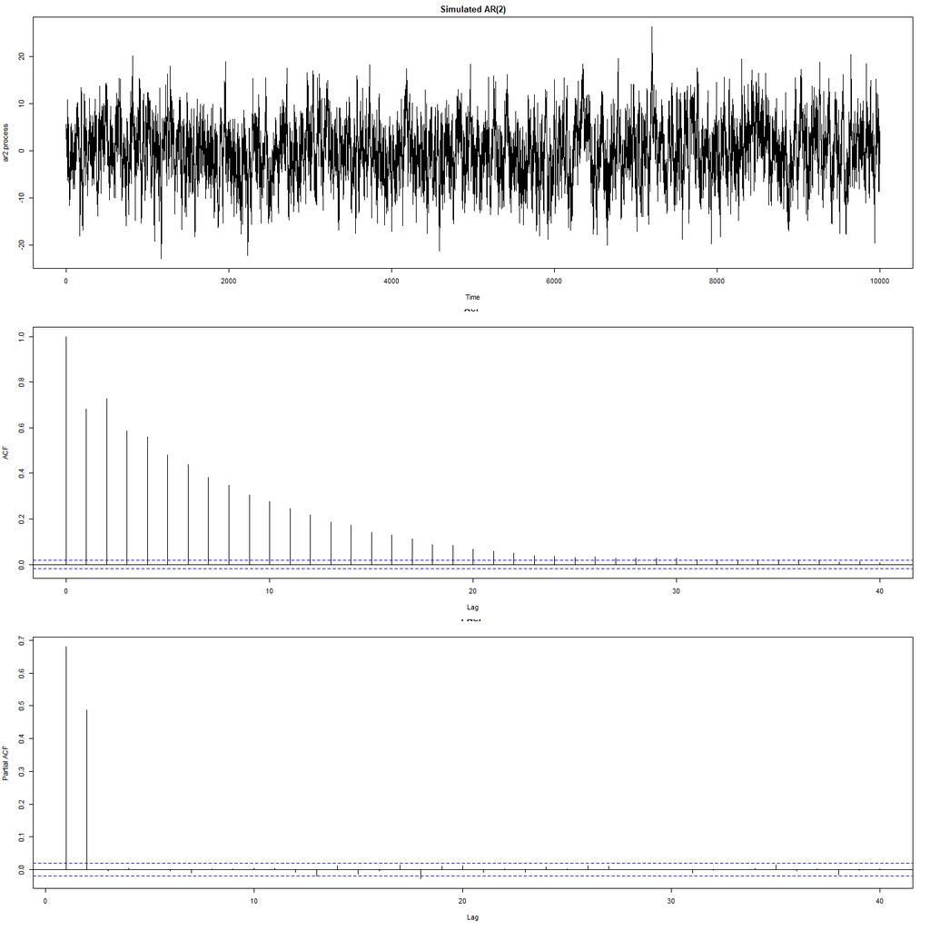

```r
pacf(ar2.process, main='PACF')
```

### AR(3)

x_t=phi1*x_(t-1)+phi2* x_(t-2)+\phi_3*x_(t-3)+z_t

z_t~ N(0, sigma^2)

```r
set.seed(2017)
sigma=4
phi=c(1/3,1/2,7/100)
n=100000

ar3.process=arima.sim(n, model=list(ar=phi), sd=sigma)

par(mfrow=c(3,1))
plot(ar3.process, main='Simulated AR(3)')
acf(ar3.process, main='ACF')
```

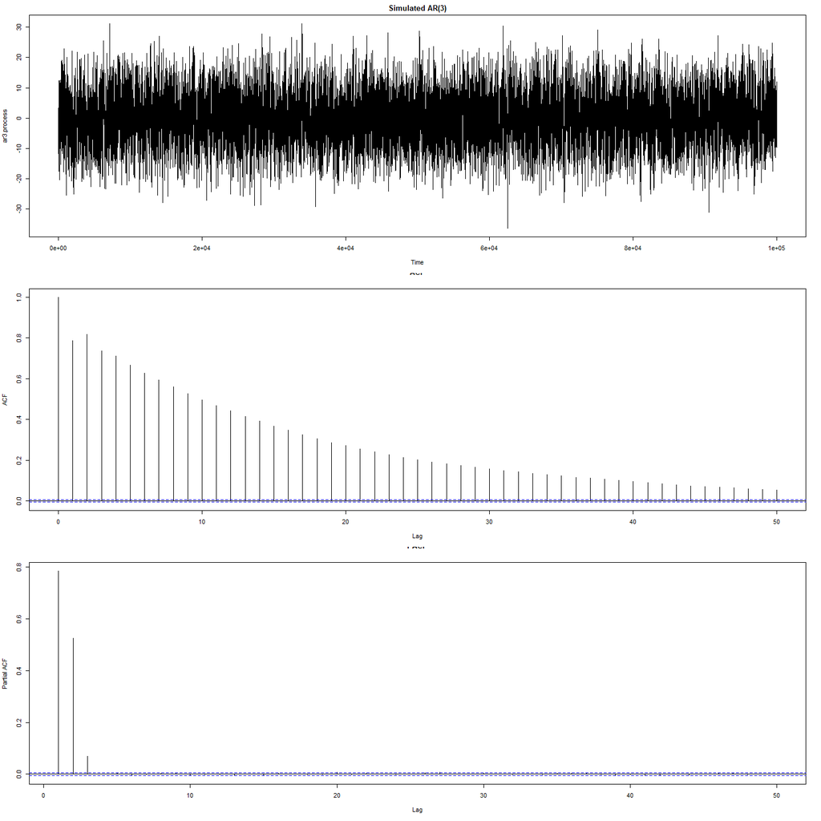

```r
pacf(ar3.process, main='PACF')
```

```r
r=NULL
r[1:3]=acf(ar3.process, plot=T)$acf[2:4]
r

R=matrix(1,3,3)
R[1,2]=r[1]
R[1,3]=r[2]
R[2,1]=r[1]
R[2,3]=r[1]
R[3,1]=r[2]
R[3,2]=r[1]
R

# b-column vector on the right
b=matrix(,3,1)# b- column vector with no entries
b[1,1]=r[1]
b[2,1]=r[2]
b[3,1]=r[3]
b

# solve Rx=b and find phi's
phi.hat=solve(R,b)
phi.hat

# sigma estimation
c0=acf(ar3.process, type='covariance', plot=F)$acf[1]
var.hat=c0*(1-sum(phi.hat*r))
var.hat
```

### AR(p)

$$X_t = \phi_0 + \phi_1 X_{t-1} + \phi_2 X_{t-2} + \cdots + \phi_p X_{t-p} + Z_t$$

$$E[X_{t-k}] = \mu, \quad E[Z_t] = 0$$

Expectation
$$\mu = \phi_0 + \phi_1 \mu + \phi_2 \mu + \cdots + \phi_p \mu + 0$$

$$X_t - \mu = \phi_1 (X_{t-1} - \mu) + \phi_2 (X_{t-2} - \mu) + \cdots + \phi_p (X_{t-p} - \mu) + Z_t$$

$$\tilde{X}_{t-k} = X_{t-k} - \mu, \quad E[\tilde{X}_t] = E[X_t] - \mu = \mu - \mu = 0$$

$$\tilde{X}_t = \phi_1 \tilde{X}_{t-1} + \phi_2 \tilde{X}_{t-2} + \cdots + \phi_p \tilde{X}_{t-p} + Z_t$$

AR(p) with null mean

$$\mu = 0$$

$$X_t = \phi_1 X_{t-1} + \phi_2 X_{t-2} + \cdots + \phi_p X_{t-p} + Z_t$$

$$\rho(k) = \begin{cases}
\phi_1\rho(k-1)+\phi_2\rho(k-2)+\cdots+\phi_p\rho(k-p), & k\geq 1\\
1 & k=0 \\
\rho(-k) & k < 0
\end{cases}$$

$$\rho(1) = \phi_1\rho(0)+\phi_2\rho(-1)+\cdots+\phi_p\rho(1-p) \\
\rho(2) = \phi_1\rho(1)+\phi_2\rho(0)+\cdots+\phi_p\rho(2-p) \\
\vdots\\
\rho(p-1) = \phi_1\rho(p-2)+\phi_2\rho(p-3)+\cdots+\phi_p\rho(1) \\
\rho(p) = \phi_1\rho(p-1)+\phi_2\rho(p-2)+\cdots+\phi_p\rho(0)$$

$$\rho(1) = \phi_1+\phi_2\rho(1)+\cdots+\phi_p\rho(p-1) \\
\rho(2) = \phi_1\rho(1)+\phi_2+\cdots+\phi_p\rho(p-2) \\
\vdots\\
\rho(p-1) = \phi_1\rho(p-2)+\phi_2\rho(p-3)+\cdots+\phi_p\rho(1) \\
\rho(p) = \phi_1\rho(p-1)+\phi_2\rho(p-2)+\cdots+\phi_p$$

$$\begin{Bmatrix}
\rho(1) \\
\rho(2) \\
\vdots \\
\rho(p-1) \\
\rho(p)
\end{Bmatrix}
=
\begin{bmatrix}
1 & \rho(1) & \rho(2) & \cdots & \rho(p-1) \\
\rho(1) & 1 & \rho(1) & \cdots & \rho(p-2) \\
\vdots & \vdots & \vdots & \vdots & \vdots \\
\rho(p-2) & \rho(p-3) & \rho(p-4) & \cdots & \rho(1) \\
\rho(p-1) & \rho(p-2) & \rho(p-3) & \cdots & 1 \\
\end{bmatrix}
\begin{Bmatrix}
\phi(1) \\
\phi(2) \\
\vdots \\
\phi(p-1) \\
\phi(p)
\end{Bmatrix}\\
b = R \phi \quad \text{unique solution}\\
R^{-1} b = \phi$$

$R$: symmetric, positive semidefinite, non-negative eigenvalues, invertible

Discrete: $r\approx\rho,\quad \hat{\phi} \approx \phi,\quad \hat{R} \approx R$

AR(2), with ($\phi_0=0$)

$$X_t = \phi_1 X_{t-1} + \phi_2 X_{t-2} + Z_t$$

$$\begin{Bmatrix}
r_1 \\
r_2
\end{Bmatrix}
=
\begin{bmatrix}
1 & r_1 \\
r_1 & 1
\end{bmatrix}
\begin{Bmatrix}
\hat{\phi}_1 \\
\hat{\phi}_2
\end{Bmatrix}$$

$$r_1 = \hat{\phi}_1 + r_1 \hat{\phi}_2 \\
r_2 = r_1 \hat{\phi}_1 + \hat{\phi}_2$$

$$Z\sim\mathcal{N}(E[Z_t]=0,V[Z_t]=\sigma_Z^2)$$

$$E[X_t] = \mu$$

$$E[X_t] = \phi_1 E[ X_{t-1} ] + \phi_2 E[ X_{t-2} ] + E [Z_t] \\
\mu = \phi_1 \mu + \phi_2 \mu + 0 = \mu (\phi_1+\phi_2) \implies \mu=0$$

$$E[X_{t-k}X_t] = \phi_1 E[ X_{t-k} X_{t-1} ] + \phi_2 E[ X_{t-k} X_{t-2} ] + E [ X_{t-k} Z_t] \\$$

$$\mathrm{COV}[X_t, X_{t+k}] = \mathrm{E}\left[ X_{t} \cdot X_{t+k} \right] - \mathrm{E}\left[ X_{t} \right] \mathrm{E}\left[ X_{t+k} \right]$$

$$\gamma(s,t) = \mathrm{Cov}[X_s,X_t] = \mathrm{E}\left[ (X_s - \mu_s) (X_t - \mu_t) \right]$$

$$V[X_t] = \phi_1^2 V[ X_{t-1} ] + \phi_2^2 V[ X_{t-2} ]
+ 2 \phi_1 \phi_2 cov(X_{t-1}, X_{t-2}) + V[Z_t]$$

TODO: VER ESSE PASSO (COMO SURGE GAMMA 0 e GAMMA 1)

$$V[X_t] = V[X_{t-1}] = V[X_{t-2}] = \gamma(0) \\
cov(X_{t-1}, X_{t-2}) = \frac{\gamma(1)}{\gamma(0)} = \rho_1$$

$$\sigma_Z^2 = \gamma(0) \left[1-\phi_1^2 - \phi_2^2 -
2 \phi_1 \phi_2 \rho_1 \right]$$

$$1-\phi_1^2 - \phi_2^2 - 2 \phi_1 \phi_2 \rho_1 \\
= 1-\phi_1^2 - \phi_1 \phi_2 \rho_1 - \phi_2^2 - \phi_1 \phi_2 \rho_1 \\
= 1-\phi_1(\phi_1 + \rho_1\phi_2) - \phi_2(\phi_2 + \phi_1 \rho_1 )$$

From the matrix equation:

$$\rho_1 = \phi_1 + \rho_1\phi_2, \quad \rho_2 = \phi_2 + \rho_1\phi_1$$

Therefore the variance:

$$\sigma_Z^2 = \gamma(0) \left[1-\phi_1\rho_1 - \phi_2\rho_2 \right] \\
\hat{\sigma}_Z^2 = c_0 \left[1-\hat{\phi}_1 r_1 - \hat{\phi}_2 r_2 \right] = c_0 \left[1- \sum_{i=1}^{p} \hat{\phi}_i r_i \right]$$

AR(3), with ($\phi_0=0$)

$$X_t = \phi_1 X_{t-1} + \phi_2 X_{t-2} + \phi_3 X_{t-3} + Z_t$$

$$\begin{Bmatrix}
r_1 \\
r_2 \\
r_3
\end{Bmatrix}
=
\begin{bmatrix}
1 & r_1 & r_2 \\
r_1 & 1 & r_1 \\
r_2 & r_1 & 1
\end{bmatrix}
\begin{Bmatrix}
\hat{\phi}_1 \\
\hat{\phi}_2 \\
\hat{\phi}_3
\end{Bmatrix}$$

```r
r=c(0.8,0.6,0.2)

R=matrix(1,3,3)
R[1,2]=r[1]
R[1,3]=r[2]
R[2,1]=r[1]
R[2,3]=r[1]
R[3,1]=r[2]
R[3,2]=r[1]
R

# b-column vector on the right
b=matrix(,3,1)# b- column vector with no entries
b[1,1]=r[1]
b[2,1]=r[2]
b[3,1]=r[3]
b

# solve Rx=b and find phi's
phi.hat=solve(R,b)
phi.hat

# sigma estimation
c0=5
var.hat=c0*(1-sum(phi.hat*r))
var.hat
```

# Week-4

## AIC

- credit: reduce the error sum of squares
- penalty: add parameters

$$𝐴𝐼𝐶 = -2 \log(MLE) + 2p$$

$$𝐴𝐼𝐶 = \log(\hat{\sigma}^2) + \frac{n + 2p}{n}, \quad \hat{\sigma}^2 = \frac{SSE}{n}$$

- $MLE$ : maximum likelihood
- $p$: number of parameters in the model
- $n$: number of samples
- $SSE$: error sum of squares

AR(2)

$$X_t = 0.7X_{t-1}-0.2X_{t-2}+Z_t$$

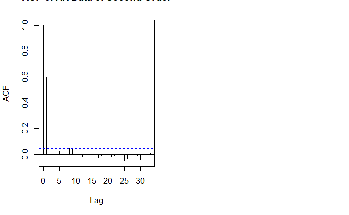

```r
#{r, fig.height=15, fig.width=15}
rm(list=ls(all=TRUE))
set.seed(43) #Roman conquest of Britain
data = arima.sim( list(order = c(2,0,0), ar =c( 0.7, -.2)), n = 2000)

par(mfrow=c(1,2))
acf(data, main="ACF of AR Data of Second Order")
acf(data, type="partial", main="PACF of Time Series")
```

```r
arima(data, order=c(2,0,0), include.mean=FALSE )
```

```
Call:
arima(x = data, order = c(2, 0, 0), include.mean = FALSE)

Coefficients:
         ar1      ar2
      0.7111  -0.1912
s.e.  0.0219   0.0220

sigma^2 estimated as 0.9985:  log likelihood = -2836.64,  aic = 5679.27
```

```r
SSE=NULL
AIC=NULL
for (p in 1:5) {
m = arima(data, order=c(p,0,0), include.mean=FALSE )
SSE[p] = sum(resid(m)^2)
AIC[p] = m$aic
print( m$coef )
print( paste(m$aic, sum(resid(m)^2)) )
}
```

```
      ar1
0.5969948
[1] "5751.73196762524 2072.83193501059"
       ar1        ar2
 0.7111457 -0.1911552
[1] "5679.27375222458 1997.00667996082"
        ar1         ar2         ar3
 0.71359315 -0.20027406  0.01281966
[1] "5680.94495534325 1996.67791506654"
         ar1          ar2          ar3          ar4
 0.713676747 -0.201599645  0.017553047 -0.006629412
[1] "5682.85704377107 1996.58997811327"
        ar1         ar2         ar3         ar4         ar5
 0.71410825 -0.20268672  0.03019322 -0.05154692  0.06293048
[1] "5676.91730818182 1988.65973372245"
```

```r
par(mfrow=c(1,2))
order=c(1,2,3,4,5)
plot(SSE~order, main="SSE plotted on Order of AR(p) Model", ylim=c(1800, 2100))
plot(AIC~order, main="AIC plotted on Order of AR(p) Model", ylim=c(5500, 5800))
```

```r
rm(list=ls(all=TRUE))
set.seed(500) #500  Seven kingdoms Kent, Essex, Sussex, Wessex, East Anglia, Mercia, and Northumbria.)
data = arima.sim( list(order = c(3,0,0), ar =c( 0.6, -0.1, .4)), n = 5000)

arima(data, order=c(2,0,0), include.mean=FALSE )
```

```
Call:
arima(x = data, order = c(2, 0, 0), include.mean = FALSE)

Coefficients:
         ar1     ar2
      0.6836  0.1586
s.e.  0.0140  0.0140

sigma^2 estimated as 1.163:  log likelihood = -7473.05,  aic = 14952.1
```

```r
arima(data, order=c(3,0,0), include.mean=FALSE )
```

```
Call:
arima(x = data, order = c(3, 0, 0), include.mean = FALSE)

Coefficients:
         ar1      ar2     ar3
      0.6195  -0.1164  0.4024
s.e.  0.0129   0.0156  0.0130

sigma^2 estimated as 0.975:  log likelihood = -7032.1,  aic = 14072.2
```

```r
arima(data, order=c(4,0,0), include.mean=FALSE )
```

```
Call:
arima(x = data, order = c(4, 0, 0), include.mean = FALSE)

Coefficients:
         ar1      ar2     ar3     ar4
      0.6188  -0.1162  0.4015  0.0015
s.e.  0.0141   0.0156  0.0156  0.0142

sigma^2 estimated as 0.9749:  log likelihood = -7032.09,  aic = 14074.19
```

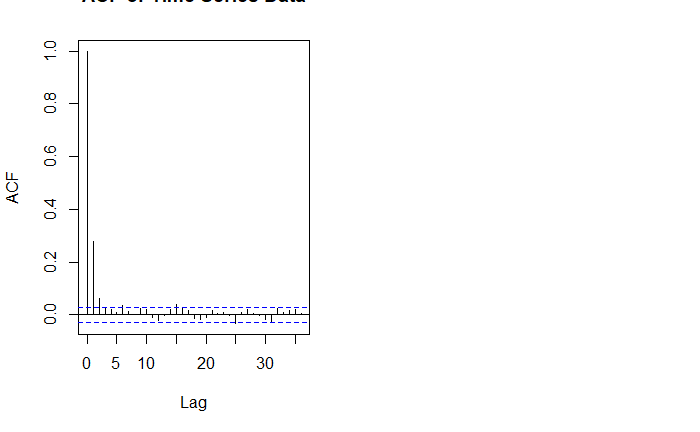

```r
rm(list=ls(all=TRUE))
set.seed(597) # Saint Augustine arrives in England
data = arima.sim( list(order = c(1,0,0), ar = .3), n = 5000)

par(mfrow=c(1,2))
acf(data, main="ACF of Time Series Data")
acf(data, type="partial", main="PACF of Time Series Data")
```

```r
arima(data, order=c(1,0,0) );
```

```
Call:
arima(x = data, order = c(1, 0, 0))

Coefficients:
         ar1  intercept
      0.2762    -0.0084
s.e.  0.0136     0.0197

sigma^2 estimated as 1.016:  log likelihood = -7134.7,  aic = 14275.4
```

```r
arima(data, order=c(2,0,0) );
```

```
Call:
arima(x = data, order = c(2, 0, 0))

Coefficients:
         ar1      ar2  intercept
      0.2804  -0.0151    -0.0085
s.e.  0.0141   0.0141     0.0194

sigma^2 estimated as 1.016:  log likelihood = -7134.13,  aic = 14276.26
```

```r
arima(data, order=c(3,0,0) );
```

```
Call:
arima(x = data, order = c(3, 0, 0))

Coefficients:
         ar1      ar2     ar3  intercept
      0.2805  -0.0181  0.0108    -0.0085
s.e.  0.0141   0.0147  0.0141     0.0196

sigma^2 estimated as 1.016:  log likelihood = -7133.84,  aic = 14277.68
```

```r
library(forecast)
data = arima.sim( n=1E4, list(ar=.5, ma=.2) )
auto.arima(data)
```

```
Series: data
ARIMA(1,0,1) with zero mean

Coefficients:
         ar1     ma1
      0.4972  0.1898
s.e.  0.0138  0.0156

sigma^2 estimated as 0.9979:  log likelihood=-14178
AIC=28362   AICc=28362   BIC=28383.63
```

## ARMA

ARMA(p,q)
$$X_t = \phi_1 X_{t-1} + \cdots + \phi_p X_{t-p} + \beta_0 Z_t + \beta_1 Z_{t-1} + \cdots + \beta_q Z_{t-q} \\
\phi(B)X_t = \beta(B)Z_t \\
\phi(B) = 1 - \phi_1 B - \cdots - \phi_p B^{p} \\
\beta(B) = \beta_0 + \beta_1 B - \cdots - \beta_q B^{q}$$
$$X_t = \sum_{i=1}^{n=p} \phi_i X_{t-i} + \sum_{i=0}^{n=q} \theta_i Z_{t-i}$$

Terms * Noise: $Z_t$ * AR: $\sum_{i=1}^{n=p} \phi_i X_{t-i}$ * MA: $\sum_{i=1}^{n=q} \theta_i Z_{t-i}$

Operators
$$\Theta(B)Z_t = \Phi(B) X_t \\
\Psi(B) = \frac{\Theta(B)}{\Phi(B)}$$

$$X_t = \frac{\Theta(B)}{\Phi(B)}Z_t = \Psi(B) Z_t$$

MA mixed
$$X_t = 0.5X_{t-1} + Z_t + 0.2 Z_{t-1} \\
(1-0.5B)X_t = (1+0.2B) Z_t \\
X_t = \frac{(1+0.2B)}{(1-0.5B)}Z_t \\
X_t = (1+0.2B)(1+0.5B+0.25B^2+0.125B^3 + \cdots)Z_t \\
X_t = (1+0.5B+0.25B^2+0.125B^3 + 0.2B + 0.1B^2+0.05B^3+0.025B^4 + \cdots)Z_t \\
X_t = (1+0.7B+0.35B^2+0.175B^3 + \cdots)Z_t \\$$

The coefficients on the polynomial should decay rather quickly.

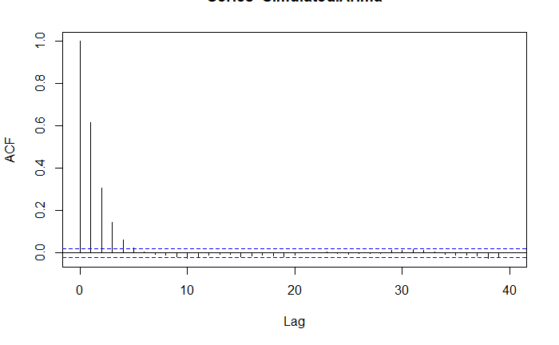

```r
phi=.5
beta=0.2
sigma=3
m=10000

set.seed(5)
Simulated.Arima =
    arima.sim(
      n=m,
      list(order = c(1,0,1),
           ar = phi,
           ma=beta)
      )
acf(Simulated.Arima)
```

## ARIMA

```r
# parameters
phi=c(.7, .2)
beta=0.5
sigma=3
m=10000

set.seed(5)
(Simulated.Arima =
    arima.sim(
      n=m,
      list(order = c(2,1,1),
           ar = phi,
           ma=beta)
      )
  )
```

```r
plot(Simulated.Arima, ylab=' ',main='Simulated time series from ARIMA(2,1,1) process', col='blue', lwd=2)
```

```r
acf(Simulated.Arima)
```

```r
Diff.Simulated.Arima=diff(Simulated.Arima)
plot(Diff.Simulated.Arima)
```

```r
acf(Diff.Simulated.Arima)
```

```r
pacf(Diff.Simulated.Arima)
```

```r
library(astsa)
sarima(Simulated.Arima,2,1,1,0,0,0) # astsa not installed
```

```r
library(forecast)
auto.arima(Simulated.Arima) # forecast not installed
```

```r
(fit1<-arima(Diff.Simulated.Arima, order=c(4,0,0)))
```

```r
(fit2<-arima(Diff.Simulated.Arima, order=c(2,0,1)))
```

```r
(fit3<-arima(Simulated.Arima, order=c(2,1,1)))
```

## Daily female births in California, 1959

The following time series is taken from Time Series Data Library (TSDL) TSDL was created by Rob Hyndman Professor of Statistics at Monash University, Australia. ====== Daily total female birth in California, 1959 ======= Data is exported as csv file to the working directory Link: https://datamarket.com/data/list/?q=cat:fwy%20provider:tsdl

```r
library(astsa)

# read data to R variable
birth.data<-read.csv("./data/daily-total-female-births-in-cal.csv")

# pull out number of births column
number_of_births<-birth.data$Daily.total.female.births.in.California..1959

# use date format for dates
birth.data$Date <- as.Date(birth.data$Date, "%m/%d/%Y")

plot.ts(number_of_births,main='Daily total female births in california, 1959', ylab = 'Number of births')
```

```r
# Test for correlation
Box.test(number_of_births, lag = log(length(number_of_births)))
```

```r
# Plot the differenced data
plot.ts(diff(number_of_births), main='Differenced series', ylab = '')
```

```r
# Test for correlation in the differenced data
Box.test(diff(number_of_births), lag = log(length(diff(number_of_births))))
```

```r
# acf of the differenced data
acf(diff(number_of_births), main='ACF of differenced data', 50)
```

```r
# pacf of the differenced data
pacf(diff(number_of_births), main='PACF of differenced data', 50)
```

```r
# Fit various ARIMA models


model1<-arima(number_of_births, order=c(0,1,1))
SSE1<-sum(model1$residuals^2)
model1.test<-Box.test(model1$residuals, lag = log(length(model1$residuals)))

model2<-arima(number_of_births, order=c(0,1,2))
SSE2<-sum(model2$residuals^2)
model2.test<-Box.test(model2$residuals, lag = log(length(model2$residuals)))

model3<-arima(number_of_births, order=c(7,1,1))
SSE3<-sum(model3$residuals^2)
model3.test<-Box.test(model3$residuals, lag = log(length(model3$residuals)))

model4<-arima(number_of_births, order=c(7,1,2))
SSE4<-sum(model4$residuals^2)
model4.test<-Box.test(model4$residuals, lag = log(length(model4$residuals)))

df<-data.frame(row.names=c('AIC', 'SSE', 'p-value'), c(model1$aic, SSE1, model1.test$p.value),
               c(model2$aic, SSE2, model2.test$p.value), c(model3$aic, SSE3, model3.test$p.value),
               c(model4$aic, SSE4, model4.test$p.value))
colnames(df)<-c('Arima(0,1,1)','Arima(0,1,2)', 'Arima(7,1,1)', 'Arima(7,1,2)')



format(df, scientific=FALSE)
```

```r
# Fit a SARIMA model

sarima(number_of_births, 0,1,2,0,0,0)
```

## Ljung-Box Q Statistic

ARMA(p,q)
$$X_t = \phi_1 X_{t-1} + \cdots + \phi_p X_{t-p} + \beta_0 Z_t + \beta_1 Z_{t-1} + \cdots + \beta_q Z_{t-q} \\
\phi(B)X_t = \beta(B)Z_t \\
\phi(B) = 1 - \phi_1 B - \cdots - \phi_p B^{p} \\
\beta(B) = \beta_0 + \beta_1 B - \cdots - \beta_q B^{q}$$

Difference operator * remove trend from non-stationary processes

$$\nabla = 1 -B$$

$$\nabla X_t = X_t - X_{t-1} = (1-B)X_t$$

Random walk
$$X_t = X_{t-1} + Z_t \\
\nabla X_t = Z_t$$

ARIMA(p,d,q) Autorregressive Integrated Moving Average of order (p,d,q)
$$Y_t := \nabla^d X_t = (1-B)^d X_t \\
Y_t \sim \text{ARMA}(p,q)
\implies
X_t \sim \text{ARIMA}(p,d,q)$$

$$\phi(B)\nabla^d X_t = \beta(B) Z_t \\
\phi(B) ( 1-B) ^d X_t = \beta(B) Z_t$$

Order of differencing $d$ * $d=1$ or $d=2$ * over differencing may introduce dependence * ACF might also suggest differencing is needed * $\phi(z)(1-z)^d$ has unit root with multiplicity $d$ * ACF will decay very slowly

ARIMA(3,0,2)
$$X_t = \phi_1 X_{t-1} + \phi_2 X_{t-2} + \phi_3 X_{t-3} + Z_t + \beta_1 Z_{t-1} + \beta_2 Z_{t-2} \\
(1-\phi_1 B - \phi_2 B^2 - \phi_3 B^3 )X_t = (1-\beta_1 B - \beta_2 B^2) Z_t$$

$$(1+0.2B)\nabla X_t = (1-0.3B)Z_t \\
(1+0.2B)(1-B) X_t = (1-0.3B)Z_t \\
(1+0.2B-B-0.2B^2) X_t = (1-0.3B)Z_t \\
(1-0.8B-0.2B^2) X_t = (1-0.3B)Z_t \\
X_t = 0.8X_{t-1} + 0.2 X_{t-2} + Z_t - 0.3Z_{t-1}$$

$$X_t = 3 X_{t-2} - 2 X_{t-3} + Z_{t} + 5 Z_{t-1} \\
( 1 - 3 B^2 + 2 B^3 )X_t = (1-5B) Z_{t} \\$$

ARIMA(2,1,1) * Since $1-3 \cdot 1^2+2 \cdot 1^3=0$, we obtain that $1-B$ divides $1-3B^2+2B^3$. * Long division would give us $1-3B^2+2B^3=(1+B-2B^2)(1-B)$. * Here $(1+B-2B^2)(1+B−2B^2)$ could be taken as AR polynomial. * Note that the factor $(1-B)$ would make the process nonstationary.

ARIMA(3,0,1) * Even though there are 2 AR terms, the order is 3 since we have $-2X_{t-3}$ * And there is 1 MA term. * Note that the process is not invertible since the root of the polynomial $1+5B$ lies inside the unit circle. How about stationarity?

ARIMA(1,2,1) * $1 −3B^2 +2B^3$ can be factorized as $(1+2B)(1-B)^2$, where we have 1 AR terms (degree of the AR polynomial $1+2B$), and two differencing $(1-B)^2$. Note that process is nonstationary. Why is that?

We have some time series whose Q-statistic at lag=4 is calculated, and corresponding p-value is found: p-value=0.340.34. What does it mean

- We do not have enough evidence to reject the null hypothesis that there is no autocorrelation UNTIL lag 4.
- The null hypothesis is $H_0: \rho_1=\rho_2=\rho_3=\rho_4=0$
- Since 0.34 is not smaller than any reasonable significance level, we cannot reject the null hypothesis.

We have some time series whose Q-statistic at lag=10 is calculated, and corresponding p-value is found: p-value=0.00034. What does it mean?

- There is a significant autocorrelation at at least one lag until lag 10.
- A low p-value is an evidence against the null hypothesis.
- We do have sufficient evidence to reject that all autocorrelation coefficients until lag 10 is zero.
- p-value if the probability of obtained data given that the null hypothesis is correct. A low p-value is an evidence against the null hypothesis.

## BJsales

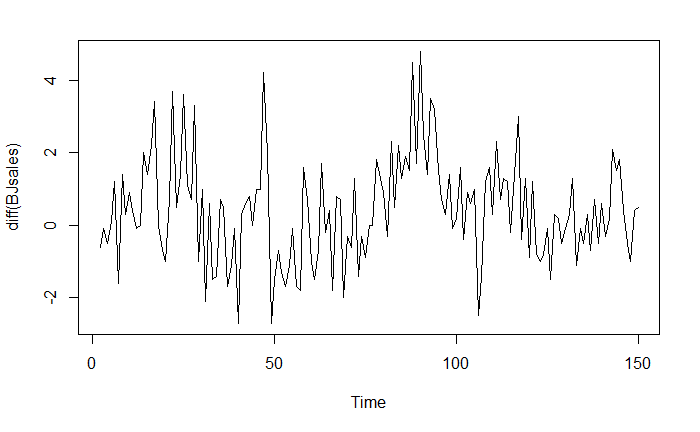

- There are ups and downs with a general upward trend.
- Time series is not stationary.
  - There is a trend which means mean is changing.

```r
plot(diff(BJsales))
```

- It does not seem to be stationary since there are still upward or downward trends in different parts of the time plot.
- There is, for example, an upward trend between (50,100) but a downward trend between (100,150). That means the mean is changing.

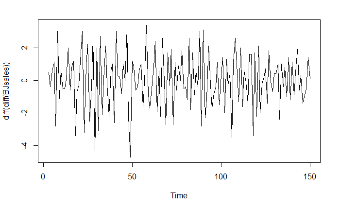

```r
plot(diff(diff(BJsales)))
```

- There is no systematic change in mean.
- Mean level seems to be constant, around 0.
- Variance towards the end of the series seems to be different from the variance in the other parts of the plot.
- It seems that variance is smaller towards the end of the plot. One may say that difference in the change of the variance is not high, and thus can be ignored.

```
Partial autocorrelations of series ‘diff(diff(BJsales))’, by lag

     1      2      3      4      5      6      7      8      9
-0.476 -0.276 -0.250 -0.082 -0.096 -0.027 -0.140  0.047 -0.036
    10     11     12     13     14     15     16     17     18
-0.200  0.028 -0.037  0.033 -0.006 -0.119 -0.063 -0.008 -0.105
    19     20     21
-0.163  0.052  0.025
```

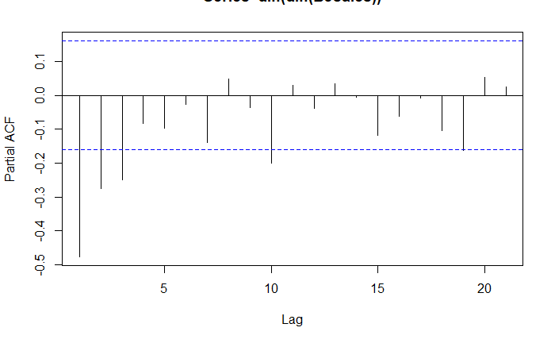

```r
(pacf(diff(diff(BJsales))))
```

- Lags: 1, 2, 3, 10, 19
- Keeping parsimony principle in mind, the order of AR terms can be 0,1,2 or 3.
- One might say that Lag 19 is barely significant.
- AR(p): PACF cuts off after p lags

```
Autocorrelations of series ‘diff(diff(BJsales))’, by lag

     0      1      2      3      4      5      6      7      8
 1.000 -0.476  0.013 -0.055  0.096 -0.070  0.047 -0.105  0.163
     9     10     11     12     13     14     15     16     17
-0.122 -0.071  0.168 -0.079  0.037 -0.045 -0.047  0.064  0.022
    18     19     20     21
-0.115  0.046  0.102 -0.069
```

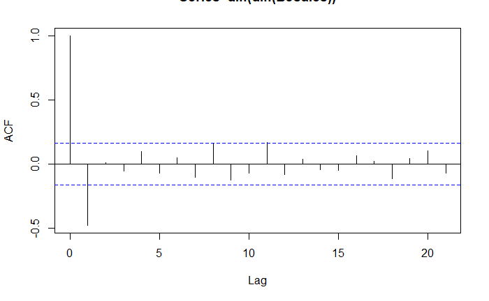

```r
(acf(diff(diff(BJsales))))
```

- Lags: 1, 8, 11
- If we ignore barely significant lags, the order of MA term can be 0 or 1.
- Lag 8 and Lag 11 are barely significant.
- MA(q): ACF cuts off after q lags
- Keeping parsimony principle in mind, the order of MA term can be 0 or 1.

```r
d=2
for(p in 1:4){
  for(q in 1:2){
        if(p+d+q<=8){
          model<-arima(x=BJsales, order = c((p-1),d,(q-1)))
          pval<-Box.test(model$residuals, lag=log(length(model$residuals)))
          sse<-sum(model$residuals^2)
          cat(p-1,d,q-1, 'AIC=', model$aic, ' SSE=',sse,' p-VALUE=', pval$p.value,'\n')
        }
      }
}
```

```
0 2 0 AIC= 577.6777  SSE= 423.7908  p-VALUE= 7.610494e-07
0 2 1 AIC= 517.1371  SSE= 276.2293  p-VALUE= 0.9632467
1 2 0 AIC= 541.9646  SSE= 327.92  p-VALUE= 0.003606979
1 2 1 AIC= 518.9734  SSE= 275.8554  p-VALUE= 0.941776
2 2 0 AIC= 532.2986  SSE= 302.7467  p-VALUE= 0.05824473
2 2 1 AIC= 520.2684  SSE= 274.0474  p-VALUE= 0.795544
3 2 0 AIC= 524.7648  SSE= 283.4941  p-VALUE= 0.7035291
3 2 1 AIC= 519.4182  SSE= 264.0684  p-VALUE= 0.6948066
```

- AIC: ARIMA(0,2,1), Smallest AIC=517.1371
- SSE: ARIMA(3,2,1), Smallest SSE value is 264.0684.

```r
model<-arima(BJsales, order=c(0,2,1))

par(mfrow=c(2,2))

plot(model$residuals)
acf(model$residuals)
```

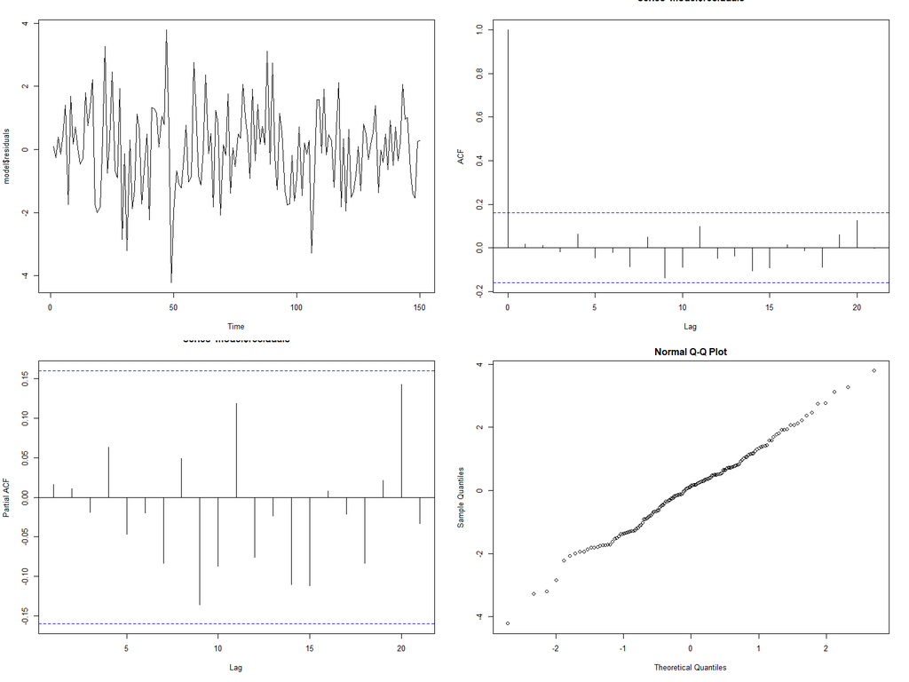

```r
pacf(model$residuals)
qqnorm(model$residuals)
```

Is there compelling evidence against the whiteness of the residuals? * No, since QQ-plot seems linear. * No, since ACF and PACF has no significant lags.

```r
summary(model)
```

```
Call:
arima(x = BJsales, order = c(0, 2, 1))

Coefficients:
          ma1
      -0.7480
s.e.   0.0662

sigma^2 estimated as 1.866:  log likelihood = -256.57,  aic = 517.14

Training set error measures:
                    ME     RMSE      MAE        MPE      MAPE
Training set 0.0164288 1.357029 1.066835 0.01198676 0.4695181
                  MASE       ACF1
Training set 0.9188348 0.01634351
```

$$Y_t = \nabla^2 X_t = (1+\beta_1 B)Z_t = Z_t +\beta_1 Z_{t-1} \\
(1-B)^2 X_t = (1-2B+B^2) X_t = (1+\beta_1 B)Z_t \\
X_t = 2X_{t-1} - X_{t-2} + Z_t +\beta_1 Z_{t-1} \\
X_t -2X_{t-1} + X_{t-2} = Z_t +\beta_1 Z_{t-1}$$

# Week-5

## SARIMA(p,d,q,P,D,Q)S

- p: $X_t$
- d
- q: $Z_t$
- P: $X_t$
- D
- Q: $Z_t$
- S: 12

S=12
$$(1+0.1B-0.2B^2)(1+0.25B^{12})X_t
= (1-0.3B)(1+0.5B^{12})Z_t\\
(1+0.1B-0.2B^2) \implies p=2 \\
(1+0.25B^{12}) \implies P=1 \\
(1-0.3B) \implies q=1 \\
(1+0.5B^{12}) \implies Q=1 \\
SARIMA(2,0,1,1,0,1)_{12} \\
(1+0.1B-0.2B^2+0.25B^{12}+0.025B^{13}-0.05B^{14})X_t
= (1+0.5B^{12}-0.3B-0.15B^{13})Z_t\\
\implies SARIMA(14,0,13,0,0,0)_1$$

There is no differencing in the process, thus $d=0$ and $D=0$. AR polynomial gives $p=2$, and seasonal AR polynomial with degree $12*1$ gives $P=1$.

The total number of parameters in this model is 27+1=28. In modeling, we prefer the simplest possible model to avoid overfitting. Including the span of the seasonality of 12 would give us a simpler model.

Seasonal AR polynomial has a degree of $24=2*12$ which gives us $P=2$.

$SARIMA(0,0,2,0,0,1)_{12}$

MA: 0.2, 0.3 SMA: 0.5 $\sigma^2_Z=1$

$$X_t = (1+0.2B+0.3B^2)(1+0.5B^{12})Z_t \\
X_t = (1+0.2B+0.3B^2+0.5B^{12}+0.1B^{13}+0.15B^{14})Z_t \\
X_t = Z_t+0.2Z_{t-1}+0.3Z_{t-2}+0.5Z_{t-12}+0.1Z_{t-13}+0.15Z_{t-14}$$

TODO: check why
$$\rho(3)=0$$

Check the name of lambda
$$X_{t-10} = Z_{t-10}+0.2Z_{t-11}+0.3Z_{t-12}+0.5Z_{t-22}+0.1Z_{t-23}+0.15Z_{t-24} \\
Z_{t-12} \implies Cov(X_t,X_{t-10}) = 0.3\cdot 0.5 = 0.15 \implies \lambda(10) = 0.15$$
$Z_{t−12}$ is common term with coefficient 0.3 and 0.5 for both equations of $X_t$ and $X_{t-10}$.

## Fit SARIMA Process

1. Time plot
2. Transformation (stationary)
3. Differencing (seasonal or non-seasonal)
4. ACF: Closers spikes: MA order
5. ACF: spikes around seasonal lags: SMA order
6. PACF: Closers spikes: AR order
7. PACF: spikes around seasonal lags: SAR order
8. Fit few different models
9. Compare AIC, SSE, choose model with minimum AIC
10. Parsimony principle (order sum <= 6)
11. Time plot, ACF, PACF of residuals
12. Ljung-Box test for residuals

## Examples

```r
x=NULL
z=NULL
n=10000

z=rnorm(n)

# TODO: CHECK WHY THIS
x[1:13]=1

for(i in 14:n){
  x[i]<-z[i]+0.7*z[i-1]+0.6*z[i-12]+0.42*z[i-13]
}

plot.ts(x[12:120], main='The first 10 months of simulation SARIMA(0,0,1,0,0,1)_12', ylab='')
```

```r
acf(x, main='SARIMA(0,0,1,0,0,1)_12 Simulation')
```

## Johnson e Johnson

```r
library(astsa)

d=1
DD=1

per=4

for(p in 1:2){
  for(q in 1:2){
    for(i in 1:2){
      for(j in 1:2){
        if(p+d+q+i+DD+j<=10){
          model<-arima(x=log(jj), order = c((p-1),d,(q-1)), seasonal = list(order=c((i-1),DD,(j-1)), period=per))
          pval<-Box.test(model$residuals, lag=log(length(model$residuals)))
          sse<-sum(model$residuals^2)
          cat(p-1,d,q-1,i-1,DD,j-1,per, 'AIC=', model$aic, ' SSE=',sse,' p-VALUE=', pval$p.value,'\n')
        }
      }
    }
  }
}
```

```r
sarima(log(jj), 0,1,1,1,1,0,4)
```

## Milk production

The time series is downloaded from TSDL.

```r
milk<-read.csv('./data/monthly-milk-production-pounds-p.csv')
Milk<-milk$Pounds
plot(Milk)
```

```r
par(mar=c(3,3,3,1))
acf2(Milk)
```

```r
plot(diff(Milk))
plot(diff(diff(Milk)))
diff2 = diff(diff(Milk),12)
plot(diff2)
```

```r
par(mar=c(3,3,3,1))
acf(diff2, lag.max=50, main='ACF')
par(mar=c(3,3,3,1))
pacf(diff2, lag.max=50, main='PACF')
```

diff2: make the process stationary ACF: q=0; Q=0,1,2,3 (seasonal at 12, 24, 36) PACF: p=0; P=0,1,2

```r
library(astsa)
library(forecast)

d=NULL
DD=NULL
d=1
DD=1

per=12
for(p in 1:1){
  for(q in 1:1){
    for(i in 1:3){
      for(j in 1:4){
        if(p+d+q+i+DD+j<=10){
          model<-arima(x=Milk, order = c((p-1),d,(q-1)), seasonal = list(order=c((i-1),DD,(j-1)), period=per))
          pval<-Box.test(model$residuals, lag=log(length(model$residuals)))
          sse<-sum(model$residuals^2)
          cat(p-1,d,q-1,i-1,DD,j-1,per, 'AIC=', model$aic, ' SSE=',sse,' p-VALUE=', pval$p.value,'\n')
        }
      }
    }
  }
}
```

```r
library(astsa)
sarima(Milk, 0,1,0,0,1,1,12)
```

$$(1-B)(1-B^{12})X_t = (1+\Theta B^{12})Z_t \\
X_t = X_{t-1} + X_{t-12} - X_{t-13} + Z_t + \Theta Z_{t-12} \\
\hat{\Theta} = - 0.675, \quad |_t \sim \mathcal{N} (\mu=0, \sigma^2=34.47)$$

```r
model<- arima(x=Milk, order = c(0,1,0), seasonal = list(order=c(0,1,1), period=12))
summary(model)
```

```r
forecast(model)
```

```r
plot(forecast(model))
```

## Sales at a souvenir shop

The time series is downloaded from TSDL. https://datamarket.com/data/set/22mh/monthly-sales-for-a-souvenir-shop-on-the-wharf-at-a-beach-resort-town-in-queensland-australia-jan-1987-dec-1993#!ds=22mh&display=line

```r
SUV<-read.csv('./data/monthly-sales-for-a-souvenir-sho.csv')
suv<-ts(SUV$Sales)

library(astsa)
library(forecast)



par(mfrow=c(2,2))

plot(suv, main='Monthly sales for a souvenir shop', ylab='', col='blue', lwd=3)
plot(log(suv), main='Log-transform of sales', ylab='', col='red', lwd=3)
plot(diff(log(suv)), main='Differenced Log-transform of sales', ylab='', col='brown', lwd=3)
plot(diff(diff(log(suv)),12), main='Log-transform without trend and seasonality', ylab='', col='green', lwd=3)
```

Assume that seasonal diff is stationary. Actually there is a variance variation.

```r
par(mar=c(3,3,3,2))
acf2(suv)
```

```r
data<-diff(diff((log(suv)),12))
par(mar=c(3,3,3,2))
acf2(data, 50)
```

ACF: q=0,1; Q=0,1,2,3 PACF: p=0,1; P=0,1

```r
d=1
DD=1
per=12
for(p in 1:2){
  for(q in 1:2){
    for(i in 1:2){
      for(j in 1:4){
        if(p+d+q+i+DD+j<=10){
          model<-arima(x=log(suv), order = c((p-1),d,(q-1)), seasonal = list(order=c((i-1),DD,(j-1)), period=per))
          pval<-Box.test(model$residuals, lag=log(length(model$residuals)))
          sse<-sum(model$residuals^2)
          cat(p-1,d,q-1,i-1,DD,j-1,per, 'AIC=', model$aic, ' SSE=',sse,' p-VALUE=', pval$p.value,'\n')
        }
      }
    }
  }
}
```

```r
model<- arima(x=log(suv), order = c(1,1,0), seasonal = list(order=c(0,1,1), period=12))
summary(model)
```

$$Y_t = \log(X_t) \\
(1-\phi B)(1-B)(1-B^{12})Y_t = (1+\Theta B^{12})Z_t \\
Y_t = (1+\phi) Y_{t-1} - phi Y_{t-2} - (1+\phi) Y_{t-13} + \phi Y_{t-14} + Z_t + \Theta Z_{t-12} \\
\hat{\phi} = - 0.5017, \quad \hat{\Theta} = - 0.5107, \quad |_t \sim \mathcal{N} (\mu=0, \sigma^2=0.03111)$$

```r
sarima(log(suv),1,1,0,0,1,1,12)
```

Residuals analysis standardized residual looks white no autocorrelation qqplot: linear, systematic departure at tails p-values no significance correlation in the residuals

```r
forecast(model)
```

```r
plot(forecast(model))
```

```r
a<-sarima.for(log(suv),12,1,1,0,0,1,1,12)

plot.ts(c(suv,exp(a$pred)), main='Monthly sales + Forecast', ylab='', col='blue', lwd=3)
```

```r
sarima(log(suv),0,1,3,0,1,1,12)
```

## USAccDeaths

1. Time plot
2. Transformation (stationary)
3. Differencing (seasonal or non-seasonal)

```r
data = USAccDeaths

library(astsa)
library(forecast)

par(mfrow=c(2,2))

plot(data, main='', ylab='', col='blue', lwd=3)
plot(log(data), main='Log-transform', ylab='', col='red', lwd=3)
```

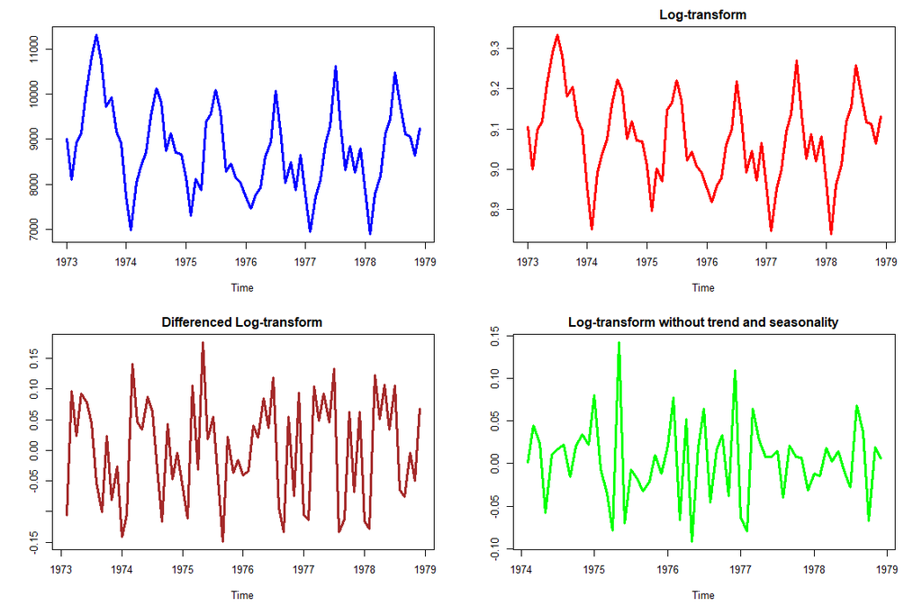

```r
plot(diff(log(data)), main='Differenced Log-transform', ylab='', col='brown', lwd=3)
plot(diff(diff(log(data)),12), main='Log-transform without trend and seasonality', ylab='', col='green', lwd=3)
```

```r
help(USAacDeaths)
```

It is a monthly time series with a span of seasonality 12. help(USAacDeaths) routine gives more information about the series including being monthly time series.

Time series is not stationary since there is a seasonal trend???? There is definitely a seasonal trend which repeats itself every 12 data points. This time series is a monthly time series.

4. ACF: Closers spikes: MA order
5. ACF: spikes around seasonal lags: SMA order
6. PACF: Closers spikes: AR order
7. PACF: spikes around seasonal lags: SAR order

```
      [,1]  [,2]  [,3]  [,4]  [,5] [,6] [,7]  [,8]  [,9] [,10] [,11] [,12] [,13] [,14] [,15] [,16] [,17] [,18] [,19]
ACF  -0.36 -0.12  0.09 -0.10  0.06 0.12 -0.2  0.00  0.10 -0.09  0.21 -0.33  0.09  0.13 -0.08 -0.05  0.16 -0.18  0.03
PACF -0.36 -0.29 -0.09 -0.16 -0.04 0.12 -0.1 -0.12 -0.02 -0.08  0.18 -0.27 -0.05  0.00 -0.01 -0.11  0.11 -0.02 -0.10
     [,20] [,21] [,22] [,23] [,24] [,25] [,26] [,27] [,28] [,29] [,30]
ACF   0.04 -0.11  0.05  0.15 -0.11 -0.04  0.08 -0.12  0.10  0.02  0.02
PACF -0.15 -0.08 -0.13  0.20 -0.05 -0.04  0.02 -0.12 -0.13  0.10  0.15
```

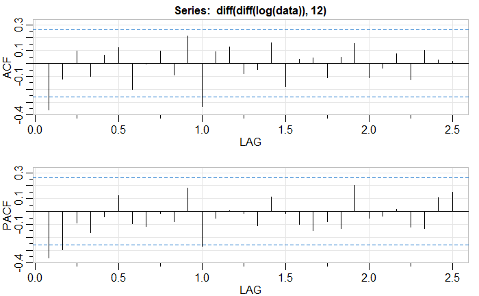

```r
#acf2(diff(data))
#acf2(diff(log(data)))
acf2(diff(diff(log(data)),12),max.lag=30)
```

We de-trend the seasonally differenced time series by taking non-seasonal differencing, diff()

The significant partial autocorrelation coefficient at lag 12 suggests the order of seasonal AR term, $P\leq 1$.

Significant adjacent lags in PACF suggest the order of AR terms, $p\leq 2$.

Significant adjacent lags in ACF suggest the order of MA terms, $q\leq 1$.

The significant autocorrelation coefficient at lag 12 suggests the order of seasonal MA term, $Q\leq 1$.

8. Fit few different models
9. Compare AIC, SSE, choose model with minimum AIC
10. Parsimony principle (order sum <= 6)

```r
d=1
DD=1
per=12
for(p in 1:2){
  for(q in 1:2){
    for(i in 1:2){
      for(j in 1:4){
        if(p+d+q+i+DD+j<=10){
          model<-arima(x=data, order = c((p-1),d,(q-1)), seasonal = list(order=c((i-1),DD,(j-1)), period=per))
          pval<-Box.test(model$residuals, lag=log(length(model$residuals)))
          sse<-sum(model$residuals^2)
          cat(p-1,d,q-1,i-1,DD,j-1,per, 'AIC=', model$aic, ' SSE=',sse,' p-VALUE=', pval$p.value,'\n')
        }
      }
    }
  }
}
```

```
0 1 0 0 1 0 12 AIC= 873.6886  SSE= 9013344  p-VALUE= 0.033192
0 1 0 0 1 1 12 AIC= 864.1295  SSE= 6850982  p-VALUE= 0.02092085
0 1 0 0 1 2 12 AIC= 865.2081  SSE= 6308828  p-VALUE= 0.03491073
0 1 0 0 1 3 12 AIC= 867.063  SSE= 5546192  p-VALUE= 0.03292021
0 1 0 1 1 0 12 AIC= 868.2989  SSE= 7745049  p-VALUE= 0.01424955
0 1 0 1 1 1 12 AIC= 865.1162  SSE= 5574898  p-VALUE= 0.033424
0 1 0 1 1 2 12 AIC= 867.112  SSE= 5577356  p-VALUE= 0.03435882
0 1 0 1 1 3 12 AIC= 868.9525  SSE= 5441390  p-VALUE= 0.03058932
0 1 1 0 1 0 12 AIC= 864.5135  SSE= 7424115  p-VALUE= 0.9166578
0 1 1 0 1 1 12 AIC= 856.88  SSE= 5863035  p-VALUE= 0.6764884
0 1 1 0 1 2 12 AIC= 858.2532  SSE= 5570112  p-VALUE= 0.7653688
0 1 1 0 1 3 12 AIC= 859.689  SSE= 4786617  p-VALUE= 0.7774272
0 1 1 1 1 0 12 AIC= 859.8826  SSE= 6464791  p-VALUE= 0.6833633
0 1 1 1 1 1 12 AIC= 858.0494  SSE= 4799977  p-VALUE= 0.7899151
0 1 1 1 1 2 12 AIC= 860.0253  SSE= 4841636  p-VALUE= 0.7799409
1 1 0 0 1 0 12 AIC= 868.244  SSE= 7928362  p-VALUE= 0.306149
1 1 0 0 1 1 12 AIC= 859.2828  SSE= 6040686  p-VALUE= 0.326346
1 1 0 0 1 2 12 AIC= 860.467  SSE= 5583769  p-VALUE= 0.4133987
1 1 0 0 1 3 12 AIC= 862.2165  SSE= 4933470  p-VALUE= 0.3788156
1 1 0 1 1 0 12 AIC= 863.2667  SSE= 6858696  p-VALUE= 0.2285597
1 1 0 1 1 1 12 AIC= 860.3391  SSE= 4945052  p-VALUE= 0.4027729
1 1 0 1 1 2 12 AIC= 862.3391  SSE= 4936869  p-VALUE= 0.403279
1 1 1 0 1 0 12 AIC= 866.2883  SSE= 7394689  p-VALUE= 0.9496107
1 1 1 0 1 1 12 AIC= 858.7786  SSE= 5869317  p-VALUE= 0.6877332
1 1 1 0 1 2 12 AIC= 860.1832  SSE= 5592896  p-VALUE= 0.7759011
1 1 1 1 1 0 12 AIC= 861.6162  SSE= 6433382  p-VALUE= 0.6935192
1 1 1 1 1 1 12 AIC= 859.9815  SSE= 4809874  p-VALUE= 0.8019513
```

11. Time plot, ACF, PACF, Ljung-Box test of residuals

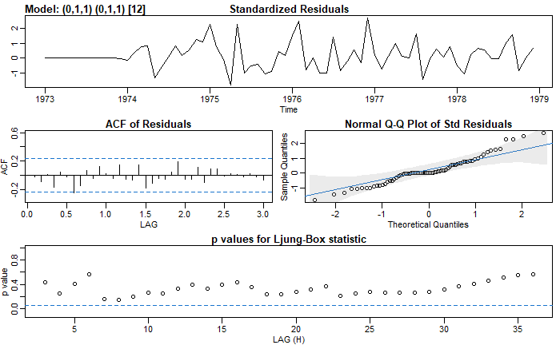

```r
m<-sarima(data,0,1,1,0,1,1,12)
```

```r
m
```

```
$fit

Call:
stats::arima(x = xdata, order = c(p, d, q), seasonal = list(order = c(P, D,
    Q), period = S), include.mean = !no.constant, transform.pars = trans, fixed = fixed,
    optim.control = list(trace = trc, REPORT = 1, reltol = tol))

Coefficients:
          ma1     sma1
      -0.4303  -0.5528
s.e.   0.1228   0.1784

sigma^2 estimated as 99347:  log likelihood = -425.44,  aic = 856.88

$degrees_of_freedom
[1] 57

$ttable
     Estimate     SE t.value p.value
ma1   -0.4303 0.1228 -3.5037   9e-04
sma1  -0.5528 0.1784 -3.0991   3e-03

$AIC
[1] 12.24114

$AICc
[1] 12.2437

$BIC
[1] 12.33018
```

There is a systematic departure from linearity in QQ-plot which implies that residuals have a heavier tail compared to the Gaussian distribution.

p-values from Ljung-Box test are high meaning that there is no significant autocorrelation left in the residuals.

ACF shows no significant autocorrelation in the residuals.

There is no strong evidence against the whiteness of the residuals.

```r
m$ttable
```

```
     Estimate     SE t.value p.value
ma1   -0.4303 0.1228 -3.5037   9e-04
sma1  -0.5528 0.1784 -3.0991   3e-03
```

```r
beta1 = m$ttable[1]
beta2 = m$ttable[2]

m$fit$sigma2
```

```
[1] 99346.89
```

```r
beta1
```

```
[1] -0.4303
```

```r
beta2
```

```
[1] -0.5528
```

```r
beta1*beta2
```

```
[1] 0.2378698
```

```r
pvalue1 = m$ttable[7]
pvalue2 = m$ttable[8]
pvalue1*1000
```

```
[1] 0.9
```

```r
pvalue2
```

```
[1] 0.003
```

```r
model<- arima(x=data, order = c(0,1,1), seasonal = list(order=c(0,1,1), period=12))
summary(model)
```

```
Call:
arima(x = data, order = c(0, 1, 1), seasonal = list(order = c(0, 1, 1), period = 12))

Coefficients:
          ma1     sma1
      -0.4303  -0.5528
s.e.   0.1228   0.1784

sigma^2 estimated as 99347:  log likelihood = -425.44,  aic = 856.88

Training set error measures:
                   ME     RMSE      MAE       MPE     MAPE      MASE        ACF1
Training set 58.83538 285.3613 200.9519 0.6651099 2.348831 0.3123172 -0.02393633
```

Forecast didn’t work with sarima, only with arima model

```r
forecast(model)
```

|  | Point Forecast | Lo 80 | Hi 80 | Lo 95 | Hi 95 |
| --- | --- | --- | --- | --- | --- |
| Jan 1979 | 8336.061 | 7931.798 | 8740.324 | 7717.794 | 8954.328 |
| Feb 1979 | 7531.829 | 7066.619 | 7997.040 | 6820.351 | 8243.307 |
| Mar 1979 | 8314.644 | 7795.594 | 8833.694 | 7520.825 | 9108.462 |
| Apr 1979 | 8616.869 | 8049.062 | 9184.676 | 7748.483 | 9485.255 |
| May 1979 | 9488.913 | 8876.216 | 10101.609 | 8551.874 | 10425.951 |
| Jun 1979 | 9859.757 | 9205.243 | 10514.272 | 8858.764 | 10860.751 |
| Jul 1979 | 10907.470 | 10213.654 | 11601.287 | 9846.369 | 11968.571 |
| Aug 1979 | 10086.508 | 9355.500 | 10817.517 | 8968.527 | 11204.489 |
| Sep 1979 | 9164.959 | 8398.561 | 9931.357 | 7992.855 | 10337.064 |
| Oct 1979 | 9384.259 | 8584.036 | 10184.483 | 8160.423 | 10608.096 |

[output cut: 14 more lines]

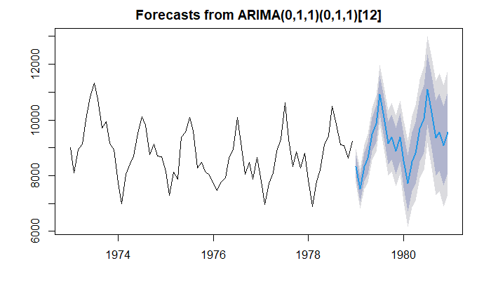

```r
plot(forecast(model))
```

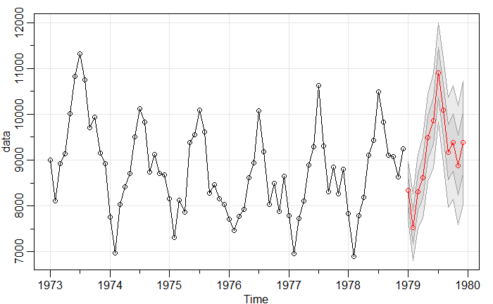

```r
a<-sarima.for(data,12,0,1,1,0,1,1,12)
```

```r
a
```

```
$pred
           Jan       Feb       Mar       Apr       May       Jun       Jul       Aug       Sep       Oct       Nov
1979  8336.061  7531.829  8314.644  8616.869  9488.913  9859.757 10907.470 10086.508  9164.959  9384.259  8884.974
           Dec
1979  9376.574

$se
          Jan      Feb      Mar      Apr      May      Jun      Jul      Aug      Sep      Oct      Nov      Dec
1979 315.4481 363.0056 405.0168 443.0623 478.0897 510.7204 541.3879 570.4090 598.0234 624.4178 649.7408 674.1133
```

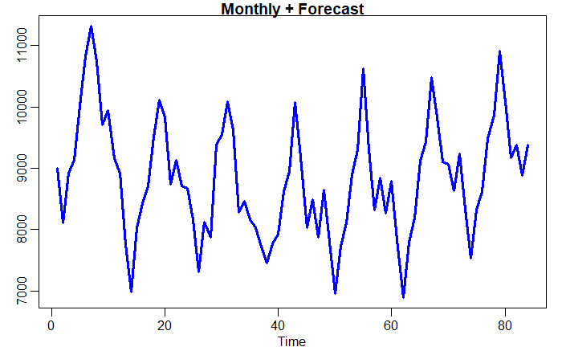

```r
plot.ts(c(data,a$pred), main='Monthly + Forecast', ylab='', col='blue', lwd=3)
```

point forecast for the number of accidental deaths in the March of 1979: 8315

## Rain in London

```r
rm(list=ls(all=TRUE))
rain.data <- scan("http://robjhyndman.com/tsdldata/hurst/precip1.dat",skip=1)
```

```
Read 100 items
```

```r
rain.ts <- ts(rain.data, start=c(1813))
```

```r
par( mfrow=c(1,2) )
hist(rain.data, main="Annual London Rainfall 1813-1912",
xlab="rainfall in inches")
qqnorm(rain.data,main="Normal Plot of London Rainfall")
```

[figure not shown]

```r
qqline(rain.data)
```

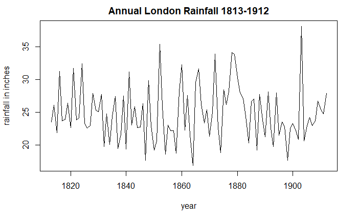

```r
plot.ts(rain.ts, main="Annual London Rainfall 1813-1912",
xlab="year", ylab="rainfall in inches")
```

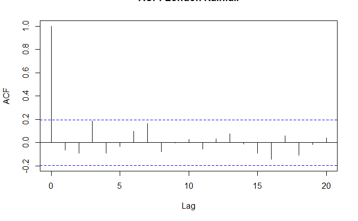

```r
acf(rain.ts, main="ACF: London Rainfall")
```

```r
library(forecast)
auto.arima(rain.ts)
```

```
Series: rain.ts
ARIMA(0,0,0) with non-zero mean

Coefficients:
         mean
      24.8239
s.e.   0.4193

sigma^2 estimated as 17.76:  log likelihood=-285.25
AIC=574.49   AICc=574.61   BIC=579.7
```

```r
alpha=.2 #increase alpha for more rapid decay
forecast.values = NULL #establish array to store forecast values
n = length(rain.data)
#naive first forecast
forecast.values [1] = rain.data[1]
#loop to create all forecast values
for( i in 1:n ) {
forecast.values [i+1] = alpha*rain.data[i] + (1-alpha)* forecast.values [i]
}
paste("forecast for time",n+1," = ", forecast.values [n+1])
```

```
[1] "forecast for time 101  =  25.3094062064236"
```

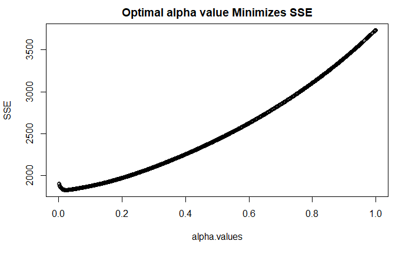

```r
SSE=NULL
n = length(rain.data)
alpha.values = seq( .001, .999, by=0.001)
number.alphas = length(alpha.values)
for( k in 1:number.alphas ) {
forecast.values=NULL
alpha = alpha.values[k]
forecast.values[1] = rain.data[1]
for( i in 1:n ) {
forecast.values[i+1] = alpha*rain.data[i] + (1-alpha)*forecast.values[i]
}
SSE[k] = sum( (rain.data - forecast.values[1:n])^2 )
}
plot(SSE~alpha.values, main="Optimal alpha value Minimizes SSE")
```

```r
index.of.smallest.SSE = which.min(SSE) #returns position 24
alpha.values[which.min(SSE)] #returns 0.024
```

```
[1] 0.024
```

```r
alpha=.024 #increase alpha for more rapid decay
forecast.values = NULL #establish array to store forecast values
n = length(rain.data)
#naive first forecast
forecast.values [1] = rain.data[1]
#loop to create all forecast values
for( i in 1:n ) {
forecast.values [i+1] = alpha*rain.data[i] + (1-alpha)* forecast.values [i]
}
paste("forecast for time",n+1," = ", forecast.values [n+1])
```

```
[1] "forecast for time 101  =  24.6771392918524"
```

```r
HoltWinters(rain.ts, beta=FALSE, gamma=FALSE)
```

```
Holt-Winters exponential smoothing without trend and without seasonal component.

Call:
HoltWinters(x = rain.ts, beta = FALSE, gamma = FALSE)

Smoothing parameters:
 alpha: 0.02412151
 beta : FALSE
 gamma: FALSE

Coefficients:
      [,1]
a 24.67819
```

## Simple Exponential Smoothing (SES)

$$\frac{1}{\alpha}= \sum_{k=0}^\infty(1-\alpha)^k$$

$$x^n_{n+h} = x^\text{time for which you actually have data}_\text{time for which you′d like a forecast}$$
$$SES: x^n_{n+1} = \alpha x_n + (1-\alpha)x^{n-1}_{n}, \quad
\text{start with }x^1_2 = x_1$$

$$SES: \hat{x}_{n+1} = \alpha x_n + (1-\alpha)\hat{x}_{n}$$

## Holt-Winters

Exponential smoothing with trend and seasonality or Triple exponential smoothing

- Levels, with parameter “alpha”, $\alpha$
- Trend, with parameter “beta”, $\beta$
- Seasonal Component , with parameter “gamma”, $\gamma$

getting a new level by updating the old level (forecast) and including new information. new level = α ⋅ new information + (1 − α) ⋅ old level
$$\hat{x}_{n+1} = \alpha x_n + (1-\alpha)\hat{x}_{n}$$

Yesterday’s forecast plus a constant times the error in yesterday’s forecast
$$\hat{x}_{n+1} = \hat{x}_{n} + \alpha (x_n - \hat{x}_{n})$$

Level (l): smoothed (S) value of ts, t for time
$$l_{t} = \alpha x_t + (1-\alpha)l_{t-1}$$

$$\hat{x}_{n+1} = \hat{l}_{n} = \alpha x_n + (1-\alpha)\hat{x}_{n}$$

(double exponential) forecast = smoothed value + correction including trend information

The one-step-ahead equations for your forecast will look like

$$\hat{x}_{n+1} = \text{level}_{n} + \text{trend}_{n}$$
Smoothed value or level
$$\text{level}_{n} = \alpha \cdot \text{new information} + (1-\alpha) (\text{old level} + \text{trend}) \\
\text{level}_{n} = \alpha \cdot x_n + (1-\alpha) (\text{level}_{n-1} + \text{trend}_{n-1})$$

Trend: weighted average of the current change in level and previous trend, similarly to what we did for SES on time series values
$$\text{trend}_{n-1} = \beta \cdot \text{new trend} + (1-\beta)\cdot\text{old trend} \\
\text{trend}_{n} = \beta \cdot (\text{level}_{n} - \text{level}_{n-1}) + (1-\beta) \text{trend}_{n-1}$$

Initial levels and trends then we can proceed inductively
$$\text{level}_1 = x_1, \quad \text{trend}_1 = x_2 − x_1$$

```r
#set up our transformed data and smoothing parameters
data = money.data.ts
N = length(data)
alpha = 0.7
beta = 0.5
##prepare empty arrays so we can store values
forecast = NULL
level = NULL
trend = NULL
#initialize level and trend in a very simple way
level[1] = data [1]
trend[1] = data [2]- data [1]
#initialize forecast to get started
forecast[1] = data [1]
forecast[2] = data [2]
#loop to build forecasts
for( n in 2:N ) {
level[n] = alpha* data [n] +
(1-alpha)*(level[n-1]+trend[n-1])
trend[n] = beta*(level[n] - level[n-1]) +
(1-beta)*trend[n-1]
forecast[n+1] = level[n] + trend[n]
}
#display your calculated forecast values
forecast[3:N]
```

```
  [1]   7287.000   7273.050   7181.698   7181.348   7179.021   7204.216   7247.049   7335.481   7408.393   7452.179
 [11]   7384.402   7395.078   7411.554   7399.153   7292.829   7268.692   7269.608   7343.870   7454.394   7591.014
 [21]   7711.445   7845.418   7907.864   7957.795   7989.996   7963.958   7840.311   7825.858   7887.022   7968.013
 [31]   8062.656   8212.969   8323.874   8463.240   8537.515   8593.568   8623.135   8593.108   8498.662   8508.946
 [41]   8600.951   8689.819   8804.043   8982.845   9173.740   9380.199   9495.617   9569.927   9660.495   9648.992
 [51]   9538.444   9566.724   9676.455   9784.115   9952.173  10094.930  10259.231  10447.041  10442.819  10537.516
 [61]  10582.895  10475.095  10296.072  10290.990  10287.719  10358.936  10470.973  10607.144  10767.995  10952.752
 [71]  11001.266  11157.477  11112.823  11021.089  10882.938  10903.464  10966.860  11121.027  11280.318  11451.194
 [81]  11639.239  11829.619  11857.466  11943.007  11997.367  11846.596  11750.407  11801.207  11906.325  12060.247
 [91]  12234.087  12423.408  12644.912  12907.394  12993.351  12951.115  12910.054  12811.967  12676.852  12765.870
[101]  12882.920  12997.164  13164.729  13375.744  13561.288  13791.150  13933.556  14032.084  14068.612  14032.107
[111]  13935.368  13983.567  14080.779  14204.169  14342.277  14575.763  14852.041  15123.910  15084.403  15100.409
[121]  15198.168  15074.487  14870.612  14781.585  14796.323  14849.631  15039.352  15287.946  15555.393  15875.239
[131]  15856.660  15943.955  16030.009  15970.422  15810.648  15836.689  15858.260  16075.341  16439.595  16702.313
[141]  16932.569  17285.297  17442.811  17599.682  17632.154  17655.842  17457.554  17514.423  17864.186  18405.500
```

[output cut: 27 more lines]

```r
#verify that we have recovered HoltWinters() output
m = HoltWinters(data, alpha = 0.7, beta = 0.5, gamma = FALSE)
m$fitted[,1]
```

```
Time Series:
Start = 1960.24996666667
End = 1994.91663333333
Frequency = 12
  [1]   7287.000   7273.050   7181.698   7181.348   7179.021   7204.216   7247.049   7335.481   7408.393   7452.179
 [11]   7384.402   7395.078   7411.554   7399.153   7292.829   7268.692   7269.608   7343.870   7454.394   7591.014
 [21]   7711.445   7845.418   7907.864   7957.795   7989.996   7963.958   7840.311   7825.858   7887.022   7968.013
 [31]   8062.656   8212.969   8323.874   8463.240   8537.515   8593.568   8623.135   8593.108   8498.662   8508.946
 [41]   8600.951   8689.819   8804.043   8982.845   9173.740   9380.199   9495.617   9569.927   9660.495   9648.992
 [51]   9538.444   9566.724   9676.455   9784.115   9952.173  10094.930  10259.231  10447.041  10442.819  10537.516
 [61]  10582.895  10475.095  10296.072  10290.990  10287.719  10358.936  10470.973  10607.144  10767.995  10952.752
 [71]  11001.266  11157.477  11112.823  11021.089  10882.938  10903.464  10966.860  11121.027  11280.318  11451.194
 [81]  11639.239  11829.619  11857.466  11943.007  11997.367  11846.596  11750.407  11801.207  11906.325  12060.247
 [91]  12234.087  12423.408  12644.912  12907.394  12993.351  12951.115  12910.054  12811.967  12676.852  12765.870
[101]  12882.920  12997.164  13164.729  13375.744  13561.288  13791.150  13933.556  14032.084  14068.612  14032.107
```

[output cut: 31 more lines]

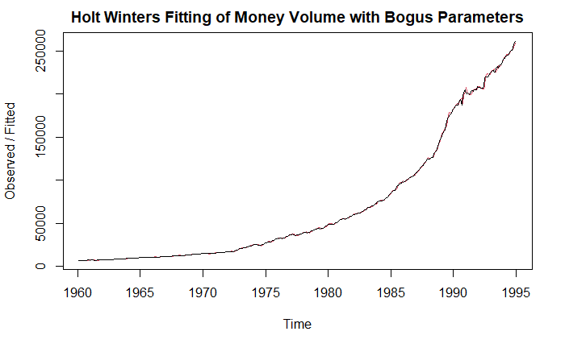

```r
plot(m, main="Holt Winters Fitting of Money Volume with Bogus Parameters")
```

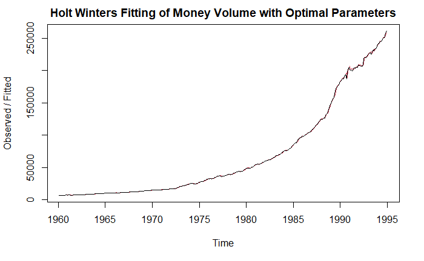

```r
m=HoltWinters(data, gamma = FALSE)
plot(m, main="Holt Winters Fitting of Money Volume with Optimal Parameters")
```

## Airline data

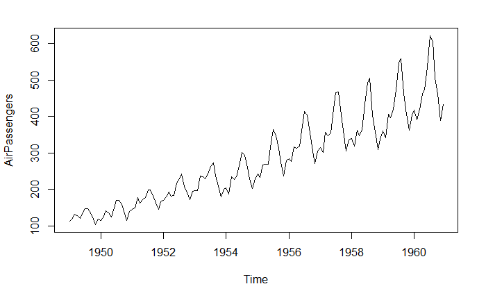

```r
plot(AirPassengers)
```

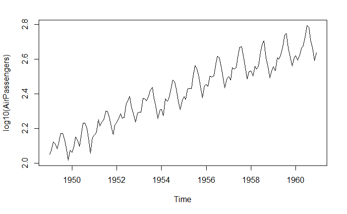

```r
plot(log10(AirPassengers))
```

- strong seasonality
- trend
- heteroscedastic, with increasing variability in later years (see first plot below)
- transform log10(number of passengers): calmer looking plot with apparently additive seasonality

We saw that SES essentially led us to naïve forecasting.

$$\hat{x}_{n+1} = \alpha x_n = x_n$$

```r
m <- HoltWinters(x = log10(AirPassengers), beta = FALSE, gamma = FALSE)
m
```

```
Holt-Winters exponential smoothing without trend and without seasonal component.

Call:
HoltWinters(x = log10(AirPassengers), beta = FALSE, gamma = FALSE)

Smoothing parameters:
 alpha: 0.9999339
 beta : FALSE
 gamma: FALSE

Coefficients:
      [,1]
a 2.635481
```

```r
m$SSE
```

```
[1] 0.3065102
```

```r
hw <- HoltWinters(x = log10(AirPassengers))
hw
```

```
Holt-Winters exponential smoothing with trend and additive seasonal component.

Call:
HoltWinters(x = log10(AirPassengers))

Smoothing parameters:
 alpha: 0.326612
 beta : 0.005744246
 gamma: 0.8207255

Coefficients:
            [,1]
a    2.680598830
b    0.003900787
s1  -0.031790733
s2  -0.061224237
s3  -0.015941495
s4   0.006307818
s5   0.014138008
s6   0.067260071
s7   0.127820295
s8   0.119893006
s9   0.038321663
s10 -0.014181699
s11 -0.085995400
s12 -0.044672707
```

```r
hw$SSE
```

```
[1] 0.0383026
```

```r
# Jan 1961
horizon = 1

(level_144 = hw$coefficients[1])  #a
(trend_144 = hw$coefficients[2])  #b
(seasonal_144_1_12 = hw$coefficients[2+horizon])  # s1

x144_1 = level_144 + horizon * trend_144 + seasonal_144_1_12
names(x144_1) <- c('x144_1')
x144_1
```

[output not shown]

```r
horizon = 8

(seasonal_144_8_12 = hw$coefficients[2+horizon])  # s1
```

```
      s8
0.119893
```

```r
x144_8 = level_144 + horizon * trend_144 + seasonal_144_8_12
names(x144_8) <- c('x144_8')
x144_8
```

```
  x144_8
2.831698
```

```r
# Dez 1961
horizon = 12

(seasonal_144_12_12 = hw$coefficients[2+horizon])  # s12
```

```
        s12
-0.04467271
```

```r
x144_12 = level_144 + horizon * trend_144 + seasonal_144_12_12
names(x144_12) <- c('x144_12')
x144_12
```

```
 x144_12
2.682736
```

```r
11%%10
```

```
[1] 1
```

```r
# Mar 1962
horizon = 15

(seasonal_144_15_12 = hw$coefficients[2+horizon%%12])  # s3
```

```
         s3
-0.01594149
```

```r
x144_15 = level_144 + horizon * trend_144 + seasonal_144_15_12
names(x144_15) <- c('x144_15')
x144_15
```

```
 x144_15
2.723169
```

```r
library(forecast)

fcast <- forecast(hw,24)
fcast
```

|  | Point Forecast | Lo 80 | Hi 80 | Lo 95 | Hi 95 |
| --- | --- | --- | --- | --- | --- |
| Jan 1961 | 2.652709 | 2.630898 | 2.674520 | 2.619351 | 2.686066 |
| Feb 1961 | 2.627176 | 2.604218 | 2.650134 | 2.592065 | 2.662287 |
| Mar 1961 | 2.676360 | 2.652297 | 2.700422 | 2.639560 | 2.713160 |
| Apr 1961 | 2.702510 | 2.677380 | 2.727640 | 2.664077 | 2.740942 |
| May 1961 | 2.714241 | 2.688076 | 2.740406 | 2.674225 | 2.754257 |
| Jun 1961 | 2.771264 | 2.744092 | 2.798436 | 2.729708 | 2.812820 |
| Jul 1961 | 2.835725 | 2.807571 | 2.863878 | 2.792667 | 2.878782 |
| Aug 1961 | 2.831698 | 2.802586 | 2.860811 | 2.787174 | 2.876222 |
| Sep 1961 | 2.754028 | 2.723977 | 2.784079 | 2.708069 | 2.799987 |
| Oct 1961 | 2.705425 | 2.674454 | 2.736396 | 2.658059 | 2.752791 |

[output cut: 14 more lines]

```r
NA
```

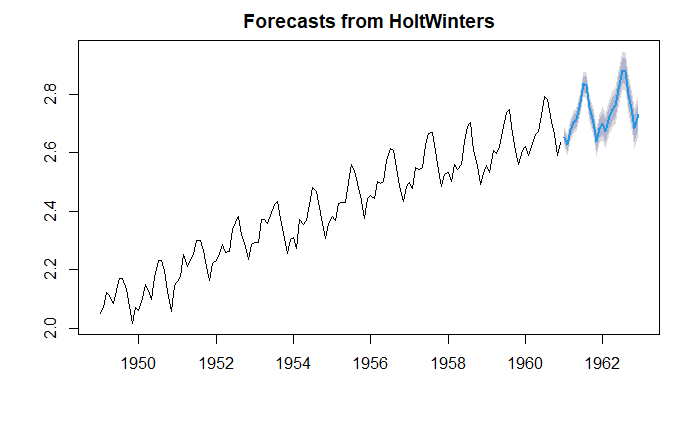

```r
plot(fcast)
```

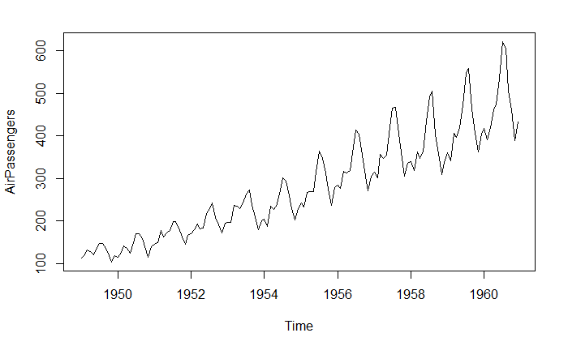

```r
plot(AirPassengers)
```

```r
hw <- HoltWinters(x = log(AirPassengers))
fcast <- forecast(hw,24,lambda=0)
```

```
biasadj information not found, defaulting to FALSE.
```

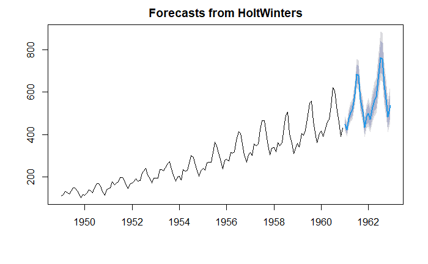

```r
plot(fcast)
```

## Lynx

[figure not shown]

```r
HoltWinters(x = lynx, beta = FALSE, gamma = FALSE)
```

```
Holt-Winters exponential smoothing without trend and without seasonal component.

Call:
HoltWinters(x = lynx, beta = FALSE, gamma = FALSE)

Smoothing parameters:
 alpha: 0.9999339
 beta : FALSE
 gamma: FALSE

Coefficients:
      [,1]
a 3395.951
```

## Austres

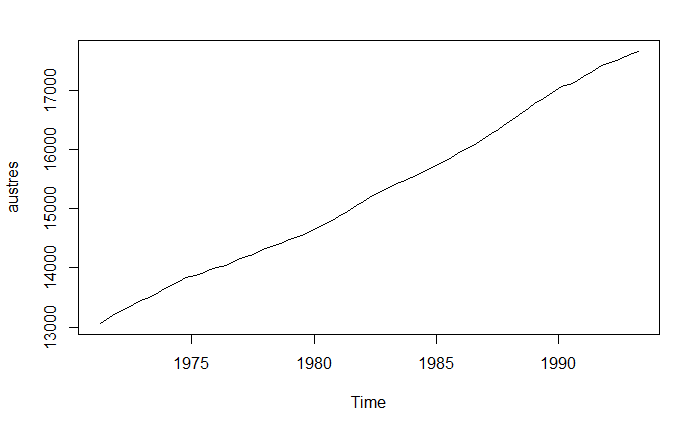

```r
plot(austres)
```

```r
hw <- HoltWinters(austres, gamma=FALSE)
hw
```

```
Holt-Winters exponential smoothing with trend and without seasonal component.

Call:
HoltWinters(x = austres, gamma = FALSE)

Smoothing parameters:
 alpha: 1
 beta : 0.4062519
 gamma: FALSE

Coefficients:
        [,1]
a 17661.5000
b    43.2471
```

```r
x_n = tail(austres,1)[1]
alpha = hw$alpha
beta = hw$beta
h=1  # 1 quarter ahead

level_n = hw$coefficients[1]  #a
trend_n = hw$coefficients[2]  #b

# level_n = alpha*x_n + (1-alpha)*(level_n_1+trend_n_1)
# trend_n = beta *(level_n-level_n_1) + (1-beta) * trend_n_1

x_n_h = level_n + h * trend_n
names(x_n_h) <- paste0('x_n_',h)
x_n_h
```

```
   x_n_1
17704.75
```

```r
forecast(HoltWinters(austres, gamma=FALSE),1)
```

|  | Point Forecast | Lo 80 | Hi 80 | Lo 95 | Hi 95 |
| --- | --- | --- | --- | --- | --- |
| 1993 Q3 | 17704.75 | 17691.8 | 17717.7 | 17684.94 | 17724.56 |

## Sunspots

[figure not shown]

```r
hw <- HoltWinters(sunspots)
hw
```

```
Holt-Winters exponential smoothing with trend and additive seasonal component.

Call:
HoltWinters(x = sunspots)

Smoothing parameters:
 alpha: 0.4856207
 beta : 0.001282363
 gamma: 0.1589522

Coefficients:
            [,1]
a    44.44311347
b    -0.01320934
s1  -12.28749771
s2   -7.25915090
s3  -11.10097642
s4   -8.53419032
s5   -7.33911912
s6   -7.40979651
s7   -6.07983391
s8   -5.52611869
s9    3.75858366
s10  -1.95658945
s11 -12.76605070
s12  -3.35905041
```

```r
x_n = tail(sunspots,1)[1]
alpha = hw$alpha
beta = hw$beta
h=4  # 1 quarter ahead

level_n = hw$coefficients[1]  #a
trend_n = hw$coefficients[2]  #b
s_h = hw$coefficients[2+h]  #s1

# level_n = alpha*x_n + (1-alpha)*(level_n_1+trend_n_1)
# trend_n = beta *(level_n-level_n_1) + (1-beta) * trend_n_1

x_n_h = level_n + h * trend_n + s_h
names(x_n_h) <- paste0('x_n_',h)
x_n_h
```

```
   x_n_4
35.85609
```

```r
forecast(hw,20)
```

|  | Point Forecast | Lo 80 | Hi 80 | Lo 95 | Hi 95 |
| --- | --- | --- | --- | --- | --- |
| Jan 1984 | 32.14241 | 10.548026 | 53.73679 | -0.8833483 | 65.16816 |
| Feb 1984 | 37.15754 | 13.145674 | 61.16941 | 0.4345577 | 73.88053 |
| Mar 1984 | 33.30251 | 7.089819 | 59.51520 | -6.7863413 | 73.39136 |
| Apr 1984 | 35.85609 | 7.608549 | 64.10362 | -7.3447930 | 79.05696 |
| May 1984 | 37.03795 | 6.887910 | 67.18799 | -9.0725564 | 83.14845 |
| Jun 1984 | 36.95406 | 5.010205 | 68.89792 | -11.8998514 | 85.80797 |
| Jul 1984 | 38.27081 | 4.624430 | 71.91720 | -13.1868893 | 89.72852 |
| Aug 1984 | 38.81132 | 3.540472 | 74.08217 | -15.1307873 | 92.75343 |
| Sep 1984 | 48.08281 | 11.255227 | 84.91040 | -8.2401190 | 104.40575 |
| Oct 1984 | 42.35443 | 4.029575 | 80.67929 | -16.2583776 | 100.96724 |

[output cut: 10 more lines]

```r
tail(sunspots)
```

```
      Jul  Aug  Sep  Oct  Nov  Dec
1983 82.2 71.8 50.3 55.8 33.3 33.4
```

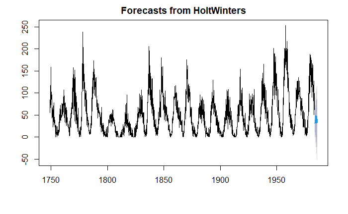

```r
fcast <- forecast(hw)
plot(fcast)
```

```r
str(df1)
```

[output not shown]

## Additive and multiplicative

Additive seasonality doesn’t care about the overall levels, whereas multiplicative seasonality does.

A nice website to explore these differences is available from Nikolaos Kourentzes: http://www.forsoc.net/2014/11/11/can-you-identify-additive-and-multiplicative-seasonality/

additive: January data add a constant to obtain the June projection multiplicative: January data mupltiply by a constant to obtain the June projection

Additive seasonality
$$\hat{x}_{n+h} = \text{level}_{n} + h\cdot\text{trend}_{n} + \text{seasonal}_{n+h-m}$$

a one-step-ahead term called $\text{trend}_{n}$, we move into the future ℎ steps in the simplest possible way by multiplying $\text{trend}_{n}$ by the number of time lags h we wish to look into the future (i.e. distance travelled is the size of your step multiplied by the number of steps).

Multiplicative seasonality
$$\hat{x}_{n+h} = (\text{level}_{n} + h\cdot\text{trend}_{n})\cdot \text{seasonal}_{n+h-m}$$

$$\text{greek letter} \cdot \text{this} + (1 − \text{greek letter}) \cdot \text{that}$$
We will peer h steps into the future for a time series with seasonality of length m. * h = number of steps into the future for forecast * m = length of the season in your data

## Forecast

1. Smooth the Level weighted average of the seasonally adjusted level $x_n − s_{n−m}$ (we say we are deseasonalizing) with the non-seasonal forecast
   $$\text{level}_{n} = \alpha \cdot (x_n - \text{seasonal}_{n-m} ) + (1-\alpha) \cdot(\text{level}_{n-1} + \text{trend}_{n-1})$$
2. Smooth the Trend
   $$\text{trend}_{n} = \beta \cdot (\text{level}_{n} - \text{level}_{n-1}) + (1-\beta)\cdot \text{trend}_{n-1}$$
3. Smooth the Season
   $$\text{seasonal}_{n} = \gamma \cdot (x_{n} - \text{level}_{n-1}) + (1-\gamma)\cdot \text{seasonal}_{n-m}$$
4. Update the Forecast Additive seasonality
   $$\hat{x}_{n+h} = (\text{level}_{n} + h\cdot\text{trend}_{n}) + \text{seasonal}_{n+h-m}$$
   Multiplicative seasonality
   $$\hat{x}_{n+h} = (\text{level}_{n} + h\cdot\text{trend}_{n})\cdot \text{seasonal}_{n+h-m}$$
   Your software will find optimal values of α and β and γ .

## Australian money

```r
#install.packages("devtools")
#devtools::install_github("FinYang/tsdl")
library(tsdl)

money.data <- subset(
  tsdl, description = "Volume of money, ABS definition m1. Feb 1960 – Dec 1994")
money.data.ts <- money.data[[1]]
#money.data.ts[162] = 22458  # NA value for July 1973
money.data.ts[162] = ( money.data.ts[161] + money.data.ts[163] ) / 2

#money.data.ts = ts(money.data[,2],start=c(1960,2) , frequency=12)
#par(mfrow=c(3,1))
plot(money.data.ts, main="Time Plot of Volume of Money")
acf(money.data.ts, main="ACF of Volume of Money")
acf(money.data.ts, type="partial", main="PACF of Volume of Money")
```

[output not shown]

Slow decay in the ACF, given the obvious trend PACF seems to cut off very sharply

## Datasets

https://pkg.yangzhuoranyang.com/tsdl/articles/tsdl.html